# Preproccessing and loading data

```python
from __future__ import print_function

import pandas as pd
import numpy as np

from depmapomics import loading, tracker, cn
from depmapomics import mutations as omics_mut
from depmapomics import terra as myterra
from genepy import terra
from genepy import mutations as mut
from genepy.utils import helper as h
from genepy.google import gcp
from gsheets import Sheets
from taigapy import TaigaClient
import dalmatian as dm
from genepy.google.google_sheet import dfToSheet

from IPython.display import Image,display
from bokeh.plotting import *

%load_ext autoreload
%autoreload 2
%load_ext rpy2.ipython
tc = TaigaClient()
output_notebook()

my_id = '~/.client_secret.json'
mystorage_id = "~/.storage.json"
# do the first steps of https://medium.com/craftsmenltd/from-csv-to-google-sheet-using-python-ef097cb014f9
creds = '../.credentials.json'

sheets = Sheets.from_files(my_id, mystorage_id)
replace = {'T': 'Tumor', 'N': 'Normal', 'm': 'Unknown', 'L': 'Unknown'}
```

## boot up

we are instanciating all the parameters needed for this pipeline to run

```python
samplesetname = "21Q2"
maxage='2020-12-01'

workspace1="terra-broad-cancer-prod/DepMap_WGS"
workspace2="terra-broad-cancer-prod/Getz_IBM_CellLines_WGS"

refworkspace="broad-firecloud-ccle/DepMap_WGS_CN"
cgaworkspace="broad-firecloud-ccle/DepMap_Mutation_Calling_CGA_pipeline-wgs"

wescnworkspace="broad-firecloud-ccle/DepMap_WES_CN_hg38"

wesmutworkspace="broad-firecloud-ccle/DepMap_Mutation_Calling_CGA_pipeline"

source1="ccle"
source2="ibm"

refsheet_url = "https://docs.google.com/spreadsheets/d/1Pgb5fIClGnErEqzxpU7qqX6ULpGTDjvzWwDN8XUJKIY"
sheeturl = "https://docs.google.com/spreadsheets/d/115TUgA1t_mD32SnWAGpW9OKmJ2W5WYAOs3SuSdedpX4"

depmap_pv = "https://docs.google.com/spreadsheets/d/1uqCOos-T9EMQU7y2ZUw4Nm84opU5fIT1y7jet1vnScE"
depmap_taiga = "arxspan-cell-line-export-f808"

release = samplesetname

WGSmethods = [
    "gatk/PreProcessingForVariantDiscovery_GATK4/8",
    "GP-TAG/Manta_SomaticSV/9",
    "gkugener/ArrayOfFilesToTxt/1",
    "vdauwera/BamToUnmappedRGBams/4",
    "gatk/CNV_Somatic_Pair_Workflow/9",
    "gkugener/Aggregate_CN_seg_files/2"
]

MutationWESmethods=[
    "broadinstitute_gtex/samtofastq_v1-0_BETA/6",
    "broadinstitute_gtex/star_v1-0_BETA/7",
    "broadinstitute_gtex/rsem_v1-0_BETA/6",
    "jkobject/rsem_aggregate_results/5",
    "jkobject/rnaseq-germline-snps-indels/7",
    "broadinstitute_gtex/rnaseqc2_v1-0_BETA/2",
    "gkugener/STAR_fusion/17",
    "jkobject/aggregate_vcfs/22",
    "gkugener/Aggregate_files_set/2",
]

CNWESmethods = [
    "gatk/PreProcessingForVariantDiscovery_GATK4/8",
    "GP-TAG/Manta_SomaticSV/9",
    "gkugener/ArrayOfFilesToTxt/1",
    "vdauwera/BamToUnmappedRGBams/4",
    "gatk/CNV_Somatic_Pair_Workflow/9",
    "gkugener/Aggregate_CN_seg_files/2"
]

extract_to_change = {'from_arxspan_id': 'participant'}

# version 102
ensemblserver = "http://nov2020.archive.ensembl.org/biomart"

# known lines:
wrongwes = {'CDS-VnMBYD', 'CDS-TGTiB8', 'CDS-8Ut3sT', 'CDS-BNyMCM', 'CDS-dgxjAa', 'CDS-ZJh6UN', 'CDS-Ip02tY', 'CDS-Rd4nMx', 'CDS-YSRYLi', 'CDS-0qPmaJ','CDS-0aJ4Yh','CDS-0lfqVz','CDS-0pZb0j','CDS-1b1Hxk','CDS-1djAlo','CDS-1p2nnc','CDS-34hKv3','CDS-3EBt51','CDS-3M6Pq9','CDS-3WygAj','CDS-49azaP','CDS-4sr6RL','CDS-5rD8XC','CDS-5wYxZS','CDS-6Yy3Yj','CDS-6da3hu','CDS-6l3V79','CDS-7PFldq','CDS-9XPgHB','CDS-9qDPiX','CDS-B0qAaq','CDS-CMenCH','CDS-CuJ0f8','CDS-Dkl8OF','CDS-Eq9UNX','CDS-FRxdcH','CDS-HNytLD','CDS-Hj3xAa','CDS-IJnjkY','CDS-Ig6N9S','CDS-KQDgIV','CDS-KYkMDa','CDS-KbbgMb','CDS-KgRznV','CDS-L0pDPl','CDS-M8xDMS','CDS-MLJbT2','CDS-MnF3x8','CDS-OCkOqy','CDS-ODmXrP','CDS-OgPf0h','CDS-PYw8ID','CDS-PdUZxY','CDS-QHp4h4','CDS-QU7ftt','CDS-QVhVDT','CDS-QXBhht','CDS-SJq3p4','CDS-Sp18uD','CDS-TpDBjm','CDS-TyWjJs','CDS-UV1pVE','CDS-UnDaBI','CDS-UtrDTK','CDS-W80jkV','CDS-WedVJA','CDS-WfjTcJ','CDS-X3c4UY','CDS-XQkXf4','CDS-XevQNc','CDS-YMIv9D','CDS-YYLKZ0','CDS-agZcmk','CDS-bntBUl','CDS-cAEii6','CDS-cYWYp7','CDS-cyuMYb','CDS-d18Xie','CDS-dpub1O','CDS-eUqT7L','CDS-eowEZF','CDS-fXMRF9','CDS-gIMBax','CDS-gRA4SM','CDS-iEULQm','CDS-ihI7Dp','CDS-iqPqOr','CDS-jqOvtj','CDS-kxNZ5S','CDS-leGxSD','CDS-nby0QM','CDS-no7ysz','CDS-o4dXGr','CDS-oHu1Ik','CDS-pXMN9C','CDS-picEuX','CDS-qZsCuJ','CDS-rLRUbG','CDS-txTRwz','CDS-uQ8nnX','CDS-yPSmxb''CDS-0qPmaJ','CDS-1PXzlf','CDS-1uWUTi','CDS-294bk6','CDS-2JxT1P','CDS-2LFZYm','CDS-2Q2Kia','CDS-2hGt1N','CDS-2lAFkD','CDS-2xSJmZ','CDS-3DHwSX','CDS-3FueNQ','CDS-3VNhFC','CDS-3jIdRa','CDS-3mvYnW','CDS-3pZIvU','CDS-49xzNU','CDS-4BrJr7','CDS-4S6juQ','CDS-4ZOQQF','CDS-4l9BUT','CDS-5H2go6','CDS-5IcijG','CDS-5LNjjI','CDS-5PXB9Y','CDS-5ViPeM','CDS-5bQzF2','CDS-5hbofu','CDS-6EyvRQ','CDS-6Fc0S5','CDS-6PZKz8','CDS-6mq2Or','CDS-6xyqy9','CDS-75psAH','CDS-7JWzyA','CDS-7nEZFG','CDS-7rcFYn','CDS-83LhEq','CDS-8aHSii','CDS-8mpXJa','CDS-8sQWae','CDS-8yHnJv','CDS-8z476r','CDS-96DdrP','CDS-9JpX07','CDS-9M8GNS','CDS-9sg0Pm','CDS-9u5DMn','CDS-9zidMf','CDS-AJMYsd','CDS-AOWMF3','CDS-AjRIMt','CDS-Awmxa5','CDS-BRxHbu','CDS-BnszE4','CDS-Bojgi7','CDS-C3hSav','CDS-C7o0op','CDS-CRPZeK','CDS-CZstO2','CDS-D6mIfI','CDS-DIckeT','CDS-DZMoWW','CDS-Eh7ost','CDS-Eo5oAR','CDS-EpURcL','CDS-EzZEgz','CDS-Fz0HXE','CDS-G1sVsw','CDS-GINQfy','CDS-GnBdHN','CDS-H1oKTL','CDS-H4hPhD','CDS-HEoDm7','CDS-HOVBCg','CDS-HjGCvC','CDS-HkZUmY','CDS-HoW111','CDS-Hv0i3y','CDS-Hw6KuA','CDS-Hx6zuD','CDS-I7bMcd','CDS-I97Uzq','CDS-IGOgCK','CDS-Iu8c04','CDS-IzeN7a','CDS-J3jfZW','CDS-J6kDsZ','CDS-JMfP1M','CDS-JvOeJK','CDS-K2tTmq','CDS-Kswf83','CDS-LCfY0q','CDS-LNTGnh','CDS-LOW19e','CDS-LUm1Vn','CDS-LVeuLY','CDS-LifesX','CDS-LnV7QY','CDS-M1sAGX','CDS-M8aV3P','CDS-MOOIHL','CDS-Md89va','CDS-MhXQX3','CDS-N83rwD','CDS-NBnCDl','CDS-NPG23x','CDS-NXnWiI','CDS-NZsio7','CDS-NjunRu','CDS-O1ShTQ','CDS-O8dfj7','CDS-OLgoE4','CDS-OWJaXi','CDS-OjLMVy','CDS-OnIxUL','CDS-OxQgBw','CDS-P79y6z','CDS-PHI8VT','CDS-PYWxsh','CDS-Pkk9e2','CDS-Pku96X','CDS-PyELSk','CDS-QE7bdY','CDS-Qbfoau','CDS-Ql8GJZ','CDS-QtTdY6','CDS-QxeMJW','CDS-R3txwY','CDS-R6ehaT','CDS-RFBAY6','CDS-RWYJ02','CDS-RnsUHX','CDS-RxQhcq','CDS-SO3AhH','CDS-SvzhGj','CDS-T10Uph','CDS-TCqSJW','CDS-TDblpN','CDS-TSDUCK','CDS-Twv1kD','CDS-Ty3mgt','CDS-UL1jLm','CDS-UVxUrF','CDS-UfC2Dz','CDS-Uru0Mh','CDS-UvBswk','CDS-UxKEaK','CDS-V2ZEuP','CDS-V6Kk5q','CDS-VBr00g','CDS-VCuHjJ','CDS-WAPQGk','CDS-WHZolj','CDS-WP95Oi','CDS-Ww1LC7','CDS-XJDBDj','CDS-Xgu4mi','CDS-XqaEOX','CDS-Y27yfi','CDS-YYd4ww','CDS-YnodyM','CDS-ZGlgTf','CDS-ZMsoXe','CDS-aDUHcI','CDS-aGMcvr','CDS-aXqwpM','CDS-allHxr','CDS-awunD8','CDS-b9sdh9','CDS-bPT1F0','CDS-bdb5iE','CDS-bons31','CDS-c2Sowd','CDS-cBOy2Z','CDS-cKMeDY','CDS-cMvnjL','CDS-ck9vpG','CDS-cmV75B','CDS-ctVpqU','CDS-dJqQ4g','CDS-dNVjOc','CDS-dPlJzz','CDS-dWHWU3','CDS-eGQYXr','CDS-eZg4P8','CDS-fLsYaB','CDS-fRpNQH','CDS-frzvLf','CDS-fs8moU','CDS-g0KUGN','CDS-gCSYjV','CDS-gKIdjs','CDS-gsqqAz','CDS-h4mOdz','CDS-hOI086','CDS-iKXYuH','CDS-iRstNJ','CDS-iX8vqU','CDS-ik526H','CDS-jHqXGP','CDS-kAARUi','CDS-kFiHZk','CDS-kt2Gne','CDS-ktRRkc','CDS-l1OClV','CDS-lSpYo6','CDS-lTogDX','CDS-ldrQm3','CDS-leyYAD','CDS-loy9vi','CDS-m49nRz','CDS-mGHY2S','CDS-mazUYU','CDS-mtMTts','CDS-n7Fqfe','CDS-nOKbmw','CDS-nTW67d','CDS-nYIBWR','CDS-ocw0rP','CDS-ogUnWk','CDS-ohjYlg','CDS-opnGD7','CDS-qIc5x3','CDS-qP2MBQ','CDS-qUtkjN','CDS-qaOoHQ','CDS-qeIIoY','CDS-qv2bpJ','CDS-r5Ym7C','CDS-rLadW7','CDS-rQIdNN','CDS-rQMY3G','CDS-rUs3FP','CDS-rVAuin','CDS-ragHOy','CDS-s7pOQR','CDS-sCWLGL','CDS-sbwn0P','CDS-sieIuO','CDS-soTPPi','CDS-tORJC8','CDS-tPR3fn','CDS-tYXity','CDS-tgnRyK','CDS-u1AlUI','CDS-uGZguG','CDS-w7i5l7','CDS-w8wJvh','CDS-wSV3OM','CDS-wWwBMZ','CDS-wbPtTZ','CDS-wlTAAF','CDS-wpXVQk','CDS-x21VqU','CDS-x7srFK','CDS-xCyamv','CDS-xI8ZAZ','CDS-xIv1KJ','CDS-xKNh7Q','CDS-yCSYHi','CDS-ycD9px','CDS-ydPJEM','CDS-z8Bvmk','CDS-ziEOXJ','CDS-zwAn7G'}

#TODO: rerun aggrgate wes with new All (without those bams)
deletedwes = {'CDS-phR2eo', 'CDS-5x4qLj', 'CDS-9TDRpv', 'CDS-NUlX3d', 'CDS-yu1s5X', 'CDS-jSUD4f', 'CDS-2jBQ8n', 'CDS-up4Vo5', 'CDS-BNyMCM', 'CDS-vrqu12', 'CDS-c51IFr', 'CDS-VS9XDY', 'CDS-363TYH', 'CDS-k9Qfva', 'CDS-RLVrVE', 'CDS-gLz8Kz', 'CDS-gJupgp', 'CDS-lIXOWR', 'CDS-pBashm', 'CDS-b5ElTm', 'CDS-6i6dRP', 'CDS-g2J7MD', 'CDS-0qPmaJ', 'CDS-59uKc2', 'CDS-ljFuDX', 'CDS-GuKG2u', 'CDS-oRM8DN', 'CDS-IQuj9W', 'CDS-bb2V33', 'CDS-pIy1EQ', 'CDS-6YFjST', 'CDS-T5BcdG', 'CDS-2HO10g'}

# samples we know have issues
wrongwes_arxspan = {'ACH-001189', 'ACH-002303', 'ACH-002315', 'ACH-002341', 'ACH-001011', 'ACH-001108', 'ACH-001187', 'ACH-002875', 'ACH-002874',
"ACH-001955", #chordoma lines
"ACH-001956",
"ACH-001957"}

# samples that failed QC but we still want to keep for now
wes_toprefer = {"CDS-Ckptje": "ACH-001672",
"CDS-pgDmZb": "ACH-002291",
"CDS-mys9Dm":"ACH-001955",
"CDS-Rl87Z1":"ACH-001956",
"CDS-TzQAjG":"ACH-001957"}

tokeep_specific_hybrid_capture = ["ACH-001187", "ACH-001011", "ACH-001108"]
```

```python
wm1 = dm.WorkspaceManager(workspace1)
wm2 = dm.WorkspaceManager(workspace2)

refwm = dm.WorkspaceManager(refworkspace).disable_hound()
cgawm = dm.WorkspaceManager(cgaworkspace).disable_hound()

wesrefwm = dm.WorkspaceManager(wescnworkspace).disable_hound()
wescgawm = dm.WorkspaceManager(wesmutworkspace).disable_hound()

ccle_refsamples = sheets.get(refsheet_url).sheets[0].to_frame(index_col=0)
#ccle_refsamples=pd.read_csv('temp/updated_ref_samples.csv',index_col=0)
```

## Adding new data

We are looking for new samples in a range of workspaces.

They are quite messy and might contains duplicates, contain broken file paths...

- We are thus looking at the bam files one by one and comparing them with our own bams.
- We remove broken files, duplicates and add new version of a cell line's bam if we find some.

```python
# we will be missing "primary disease","sm_id", "cellosaurus_id", "gender, "age", "primary_site", "primary_disease", "subtype", "subsubtype", "origin", "comments"
#when SMid: match==
samples, pairs, noarxspan = loading.GetNewCellLinesFromWorkspaces(refworkspace, stype='wgs', maxage=maxage, refurl=refsheet_url, wmfroms = [workspace1, workspace2], sources=[source1, source2], match=['ACH-','CDS-'], participantslicepos=10, accept_unknowntypes=True, extract=extract_to_change)
```

```
refsamples is overrided by a refurl
Getting sample infos...

The shape of the sample tsv from <dalmatian.wmanager.WorkspaceManager terra-broad-cancer-prod/DepMap_WGS>: (129, 233)
Identifying any true duplicates by checking file hashes (this runs for each data source)...
This step can take a while as we need to use gsutil to check the size of each potential duplicate...
listing files in gs
These 0 bam file path do not exist: set()
listing files in gs
```

```
listing files in gs
```

```
listing files in gs
listing files in gs
we found and removed 0 samples which did not match our id names: ['ACH-', 'CDS-']
found 69 likely replicate
listing files in gs
Len of samples before removal: 98
Dups from this workspace has len 21:
 ['gs://fc-d2a92869-a028-40cf-a400-6ce6f7a5e92b/DepMap_CellLine_WGS_June2020/RP-1561/WGS/SNU2372_1/v1/SNU2372_1.bam', 'gs://fc-d2a92869-a028-40cf-a400-6ce6f7a5e92b/DepMap_CellLine_WGS_June2020/RP-1561/WGS/UPCISCC131/v1/UPCISCC131.bam', 'gs://fc-d2a92869-a028-40cf-a400-6ce6f7a5e92b/DepMap_CellLine_WG…
Len of samples after removal: 77

The shape of the sample tsv from <dalmatian.wmanager.WorkspaceManager terra-broad-cancer-prod/Getz_IBM_CellLines_WGS>: (14, 233)
Identifying any true duplicates by checking file hashes (this runs for each data source)...
This step can take a while as we need to use gsutil to check the size of each potential duplicate...
listing files in gs
These 0 bam file path do not exist: set()
listing files in gs
listing files in gs
listing files in gs
listing files in gs
we found and removed 0 samples which did not match our id names: ['ACH-', 'CDS-']
found 4 likely replicate
listing files in gs
Len of samples before removal: 13
Dups from this workspace has len 3:
 ['gs://fc-49b66034-d2f1-4d65-84db-891ae1be11d4/Getz_IBM_CellLine_WGS_June2020/RP-1561/WGS/CORL26/v1/CORL26.bam', 'gs://fc-49b66034-d2f1-4d65-84db-891ae1be11d4/Getz_IBM_CellLine_WGS_June2020/RP-1561/WGS/Set2_/v1/Set2_.bam', 'gs://fc-49b66034-d2f1-4d65-84db-891ae1be11d4/Getz_IBM_CellLine_WGS_June2020…
Len of samples after removal: 10
we had 0 duplicates in the release buckets
found 0 matched normals
removed: 1 samples from size alone (too similar to a replicate)
removed: 4 samples with duplicat PDO ids
removed: 50 samples that have not changed since last time (likely     duplicate having been removed)
```

### finding back arxspan

```python
noarxspan = tracker.retrieveFromCellLineName(noarxspan, ccle_refsamples, datatype='wgs', arxspan_id="arxspan_id", depmappvlink = depmap_pv)
samples = pd.concat([samples, noarxspan[noarxspan.arxspan_id!='0']], sort=False)
noarxspan = noarxspan[noarxspan.arxspan_id=='0']
noarxspan
```

```
we found and removed 0 samples which did not match our id names: ['ACH', 'CDS']
found 0 likely replicate
listing files in gs
Len of samples before removal: 23
Dups from this workspace has len 0:
 []
Len of samples after removal: 23
```

[output not shown]

```python
noarxspan['stripped_cell_line_name'] = ['SMZ1']
noarxspan['arxspan_id'] = ['ACH-001197']
noarxspan
```

| sample_id | legacy_bam_filepath | legacy_bai_filepath | stripped_cell_line_name | arxspan_id | sequencing_date | participant_id | crc32c_hash | size | PDO | update_time |
| --- | --- | --- | --- | --- | --- | --- | --- | --- | --- | --- |
| CDS-FylkjA | gs://fc-d2a92869-a028-40cf-a400-6ce6f7a5e92b/D... | gs://fc-d2a92869-a028-40cf-a400-6ce6f7a5e92b/D... | SMZ1 | ACH-001197 | 737686 | PT-S352VysG | 7v5+NA== | 106808557758 | PDO-22386 | 2021-01-13 |

```python
samples = pd.concat([samples, noarxspan[noarxspan.arxspan_id!='0']], sort=False)
noarxspan = noarxspan[noarxspan.arxspan_id=='0']
noarxspan
```

|  | legacy_bam_filepath | legacy_bai_filepath | stripped_cell_line_name | arxspan_id | sequencing_date | participant_id | crc32c_hash | size | PDO | update_time |
| --- | --- | --- | --- | --- | --- | --- | --- | --- | --- | --- |
| sample_id |  |  |  |  |  |  |  |  |  |  |

```python
samples = loading.assessAllSamples(samples, ccle_refsamples, stype='wgs', rename={}, extract={})
```

```
we had 0 duplicates in the release buckets
```

## getting the addtional data and writing it here in the right order 'as shown above'

- use the stripped_cell_line_name to find the samples on https://docs.google.com/spreadsheets/d/1uqCOos-T9EMQU7y2ZUw4Nm84opU5fIT1y7jet1vnScE/edit#gid=356471436.
- Make sure that we don't have duplicate cell lines in there. Otherwise, use the duplicate renaming function
- copy Primary Site, Primary Disease, Subtype, Comments, Disease Sub-subtype, if they exist. (sometimes subtype and subsubtype are the same.. don't use subsubtype then.
- look for the cell line in cellosaurus, you might need to use one of the aliases given in master depmap pv..
- copy cellosaurus_id gender age info or write 'U' if they don't exist. 'can be a number or {Embryonic, Children, Adult, Fetus, U}
- check that it does not say this cell line is not a duplicate from another cell line
- check that if it says this cell line is derived/children/father/samepatient from other cell lines, and that if we have any of the other cell lines, that the patient id is changed to be the same one for all (be sure that you are updating everywhere these patient ids are used)

```python
# If I have a previous samples I can update unknown data directly
samples, notfound = tracker.updateFromTracker(samples, ccle_refsamples)
samples.loc[notfound]
```

[output not shown]

```python
#add data for not found
samples = completeFromMasterSheet(samples, notfound)
```

```python
dfToSheet(samples.loc[notfound], "depmap samples not found WGS", creds)
```

```python
dfToSheet(samples, "depmap ALL samples found WGS", creds)
```

```python
noarxspan.sort_values(by = 'stripped_cell_line_name').to_csv('temp/noarxspan_wgs_' + release + '.csv')
samples.loc[notfound].to_csv('temp/notfound_wgs_'+release+'.csv')
samples.to_csv('temp/new_wgs_'+release+'.csv')
```

```python
updated_samples = sheets.get("https://docs.google.com/spreadsheets/d/1tldMX-DBhA6LNu_RLl_vgYff_40YFMSMwuQXjQZJr54").sheets[0].to_frame().set_index('sample_id')
```

```python
samples.loc[updated_samples.index, updated_samples.columns] = updated_samples.values
```

```python
dfToSheet(samples, 'depmap ALL samples found WGS', secret=creds)
```

```python
# uploading to our bucket (now a new function)
aa = terra.changeToBucket(samples,'gs://cclebams/wgs/', name_col= "index" , values=['legacy_bam_filepath','legacy_bai_filepath'], filetypes=['bam', 'bai'], catchdup=True, test=False)
```

```
CDS-kQrJXE.bam already exists in the folder: gs://cclebams/wgs/
listing files in gs
['98635863442  2021-03-15T19:52:52Z  gs://cclebams/wgs/CDS-kQrJXE.bam#1615837972426816  metageneration=1']
CDS-kQrJXE.bai already exists in the folder: gs://cclebams/wgs/
listing files in gs
['   8875792  2021-03-15T19:52:54Z  gs://cclebams/wgs/CDS-kQrJXE.bai#1615837974504189  metageneration=1']
CDS-ch2aVd.bam already exists in the folder: gs://cclebams/wgs/
listing files in gs
['120731536581  2021-03-15T19:52:56Z  gs://cclebams/wgs/CDS-ch2aVd.bam#1615837976467729  metageneration=1']
CDS-ch2aVd.bai already exists in the folder: gs://cclebams/wgs/
listing files in gs
['   8898392  2021-03-15T19:52:58Z  gs://cclebams/wgs/CDS-ch2aVd.bai#1615837978480330  metageneration=1']
```

```python
ccle_refsamples = sheets.get(refsheet_url).sheets[0].to_frame(index_col=0)
```

```python
names=[]
subccle_refsamples = ccle_refsamples[ccle_refsamples['datatype'] == "wgs"]
for k, val in samples.iterrows():
    val = val["arxspan_id"]
    names.append(val)
    samples.loc[k, 'version'] = len(subccle_refsamples[subccle_refsamples['arxspan_id'] == val]) + names.count(val)
samples['version'] = samples['version'].astype(int)
```

```python
# do we have duplicates
samples[samples.version>1]
```

|  | legacy_bam_filepath | legacy_bai_filepath | stripped_cell_line_name | arxspan_id | sequencing_date | participant_id | crc32c_hash | size | PDO | update_time | ... | age | primary_site | subtype | subsubtype | origin | parent_cell_line | matched_normal | comments | mediatype | condition |
| --- | --- | --- | --- | --- | --- | --- | --- | --- | --- | --- | --- | --- | --- | --- | --- | --- | --- | --- | --- | --- | --- |
| sample_id |  |  |  |  |  |  |  |  |  |  |  |  |  |  |  |  |  |  |  |  |  |

0 rows × 25 columns

```python
ccle_refsamples = ccle_refsamples.append(samples, sort=False)
```

```python
for val in samepatient:
    sub = ccle_refsamples[ccle_refsamples.arxspan_id.isin(val)]
    if len(set(sub.participant_id))>2:
        print('we found a missig participant relationship')
        # ccle_refsamples.loc[ccle_refsamples.index, "participant_id"]=sub.participant_id[0]
```

```python
dfToSheet(ccle_refsamples,'ccle sample tracker', secret=creds)
```

```python
#pairs = setupPairsFromSamples(samples, subccle_refsamples, extract={'patient_id':'participant_id'})
```

[output not shown]

```python
#uploading new samples to mut
refwm.upload_samples(samples)
#refwm.upload_entities('pairs', pairs)
#refwm.update_pair_set(pair_set_id=samplesetname,pair_ids=pairs.index)
sam = refwm.get_samples()

#pair = refwm.get_pairs()
#refwm.update_pair_set(pair_set_id='all',pair_ids=pair.index)
#creating a sample set
refwm.update_sample_set(sample_set_id=samplesetname, sample_ids=samples.index)
refwm.update_sample_set(sample_set_id='all', sample_ids=[i for i in sam.index.tolist() if i!='nan'])
```

```
Successfully imported 56 participants.
Successfully imported 56 samples.
Successfully imported 1 sample sets:
  * 21Q2 (56 samples)
Sample set "all" (468 samples) successfully updated.
```

```python
myterra.copyToWorkspace(refworkspace,ccle_refsamples)
```

```
found these columns to be missing in workspace: {'bam_public_sra_path', 'sm_id', 'patient_id', 'condition', 'ccle_name', 'sequencing_type', 'matched_normal'}
found these to be unmatched: set()
Successfully updated attributes '['arxspan_id', 'version', 'sm_id', 'datatype', 'size', 'ccle_name', 'stripped_cell_line_name', 'patient_id', 'cellosaurus_id', 'bam_public_sra_path', 'internal_bam_filepath', 'internal_bai_filepath', 'parent_cell_line', 'sex', 'matched_normal', 'age', 'primary_site',…
```

```python
#and CGA
cgawm.upload_samples(samples)
sam = cgawm.get_samples()
#creating a sample set
cgawm.update_sample_set(sample_set_id=samplesetname, sample_ids=samples.index)
cgawm.update_sample_set(sample_set_id='all', sample_ids=[i for i in sam.index.tolist() if i!='nan'])
```

```
Successfully imported 56 participants.
Successfully imported 56 samples.
Successfully imported 1 sample sets:
  * 21Q2 (56 samples)
Sample set "all" (468 samples) successfully updated.
```

```python
myterra.copyToWorkspace(cgaworkspace,ccle_refsamples)
```

```
found these columns to be missing in workspace: {'bam_public_sra_path', 'sm_id', 'patient_id', 'condition', 'baits', 'ccle_name', 'sequencing_type', 'matched_normal'}
found these to be unmatched: set()
Successfully updated attributes '['arxspan_id', 'version', 'sm_id', 'datatype', 'size', 'ccle_name', 'stripped_cell_line_name', 'patient_id', 'cellosaurus_id', 'bam_public_sra_path', 'internal_bam_filepath', 'internal_bai_filepath', 'parent_cell_line', 'sex', 'matched_normal', 'age', 'primary_site',…
```

# run the pipeline

- For new samples in DepMap, run the ICE version of this task. CCLE2 samples used Agilent targets, so this pipeline should be used instead. The pipelines are identical in terms of their outputs, but the proper targets, baits, and pseudo normal should be used based on how the samples were sequenced.

  **ICE_CGA_Production_Analysis_Pipeline_Cell_Lines_copy** (cclf/CGA_Production_Analysis_Pipeline_Cell_Lines_debuggingSnapshot ID: 22) OR

```
**AGILENT_CGA_Production_Analysis_Pipeline_Cell_Lines** (cclf/CGA_Production_Anablysis_Pipeline_Cell_Lines_debuggingSnapshot ID: 22)
```

- **common_variant_filter** (breardon/common_variant_filterSnapshot ID: 3)
- **filterMAF_on_CGA_pipeline** (gkugener/filterMAF_on_CGA_pipelineSnapshot ID: 8)
- **aggregateMAFs_selectFields** (ccle_mg/aggregateMAFs_selectFieldsSnapshot ID: 1)

This outputs to be downloaded will be saved in the sample set that was run. The output we use for the release is:

- **passedCGA_filteredMAF_aggregated**

There are several other tasks in this workspace. In brief:

- **CGA_Production_Analysis_Pipeline_Cell_Lines** (lelagina/CGA_Production_Analysis_Pipeline_Cell_LinesSnapshot ID: 12). This task is the same as the ICE and AGILENT prefixed version above, except that it relied on pulling the baits and targets to use from the metadata stored for the samples. Having AGILENT and ICE versions specified made the uploading and running process easier.
- **SANGER_CGA_Production_Analysis_Pipeline_Cell_Lines** (cclf/CGA_Production_Analysis_Pipeline_Cell_Lines_debuggingSnapshot ID: 22). This task was trying to run the CGA pipeline on the Sanger WES data, using a Sanger pseudo normal. In its current implementation, this task fails to complete for the samples.
- **UNFILTERED_aggregateMAFs_selectFields** (ccle_mg/aggregateMAFs_selectFieldsSnapshot ID: 1). Aggregates the MAF outputted by the CGA cell line pipeline prior to the common variant filter and germline filtering tasks. This can give us insight to which mutations are getting filtered out when. We may want to potentially include this MAF in the release so people can see why certain mutations of interest may be getting filtered out.
- WES_DM_Mutation_Calling*Pipeline*(standard |expensive) (gkugener/WES_DM_Mutation_Calling_PipelineSnapshot ID: 2). This was a previous mutation calling pipeline implemented for CCLE. We do not use this pipeline any more as the CGA pipeline looks better.
- aggregate_filterMAF_CGA (CCLE/aggregate_filterMAF_CGASnapshot ID: 1). An aggregation MAF task that we used in the past. We do not use this task anymore.
- calculate_mutational_burden (breardon/calculate_mutational_burdenSnapshot ID: 21). This task can be used to calculate the mutational rate of the samples. We do not make use of this data in the release although it could be of interest.
- summarizeWigFile (breardon/summarizeWigFileSnapshot ID: 5). CCLF ran this task (might be necessary for the mutational burden task). For our workflow, we do not run it.

### cleaning workspaces

```python
for workspaceid in [refworkspace, cgaworkspace]:
    torm = terra.deleteHeavyFiles(workspaceid)
    h.parrun(['gsutil rm '+i for i in torm], cores=8)
    terra.removeFromFailedWorkflows(workspaceid, dryrun=False, everythingFor=['Realign_WES_GATK4','Generate_uBAM_File_List','BamToUnmappedRGBams_MC','CGA_WES_CCLE_ICE','CGA_WES_CCLE_AGILENT'])
```

```
we got 125409 files
we might remove more than 371538.335098596GB
```

## On Terra

### calling mutations

```python
submission_id1 = cgawm.create_submission("CGA_WES_CCLE_Characterization_Pipeline_v0.1_Jul2019_copy", samplesetname,'sample_set',expression='this.samples')
```

```
Successfully created submission 62a69018-fa18-4d2f-83a7-4dc62eced279.
```

### Aligning to hg38

```python
unmap = "BamToUnmappedRGBams"
groupfiles= "ArrayOfFilesToTxt"
mapping = "PreProcessingForVariantDiscovery_GATK4"
```

```python
submission_id2 = refwm.create_submission(unmap, samplesetname,'sample_set',expression='this.samples')
await terra.waitForSubmission(refworkspace, submission_id2)
```

```
Successfully created submission 5d228bc6-fd70-4634-b372-f6c40c49a242.
```

```python
submission_id2 = refwm.create_submission(groupfiles, samplesetname,'sample_set',expression='this.samples')
await terra.waitForSubmission(refworkspace, submission_id2)
```

```
status is: Failed for 0 jobs in submission 0. 1017 mn elapsed..
```

```python
submission_id2 = refwm.create_submission(mapping, samplesetname,'sample_set',expression='this.samples')
await terra.waitForSubmission(refworkspace, submission_id2)
```

```
1.0 of jobs Succeeded in submission 0.
Successfully created submission d299994d-c338-46ac-a20c-caddf56cb900.
```

```python
submission_id2 = refwm.create_submission("cnn-variant-filter", samplesetname,'sample_set',expression='this.samples')
submission_id3 = refwm.create_submission("CNV_Somatic_Workflow_on_Sample", samplesetname,'sample_set',expression='this.samples')
submission_id4 = refwm.create_submission("Manta_SomaticSV", samplesetname,'sample_set',expression='this.samples')
```

```
Successfully created submission 4c4ddfa0-bd00-4342-8c2f-cab907bfaba9.
Successfully created submission 22679ab7-9123-41a1-b7bb-17f925c1fe04.
Successfully created submission cb0c2566-8943-41af-803a-d9f18453bd3d.
```

```python
await terra.waitForSubmission(cgaworkspace, submission_id1)
submission_id1 = cgawm.create_submission("common_variant_filter", samplesetname, 'sample_set', expression='this.samples')
await terra.waitForSubmission(cgaworkspace, submission_id1)
```

```python
submission_id1 = cgawm.create_submission("filterMAF_on_CGA_pipeline", samplesetname,'sample_set',expression='this.samples')
await terra.waitForSubmission(cgaworkspace, submission_id1)
```

### aggregations

```python
# adding to the allcurrent
terra.addToSampleSet(cgaworkspace, 'allcurrent', cgawm.get_sample_sets().loc[samplesetname].samples)
```

```
Sample set "allcurrent" (137 samples) successfully updated.
```

```python
#filtered
submission_id1 = cgawm.create_submission("aggregateMAFs_selectFields_copy", 'allcurrent')
#unfiltered
submission_id5 = cgawm.create_submission("aggregateMAFs_selectFields_unfiltered", 'allcurrent')
```

```
Successfully created submission 4751bf49-6339-493d-9be0-9a30c057f301.
Successfully created submission 5f4defcc-b813-4980-85a6-0da97e996ad7.
```

```python
terra.waitForSubmission(refworkspace, [submission_id2,submission_id3,submission_id4])
#submission_id4 = refwm.create_submission("aggregate_vcfs_snp", "all")
submission_id2 = refwm.create_submission("Aggregate_CN_seg_files", "all")
```

```python
#submission_id2 = refwm.create_submission("aggregate_vcfs_sv", "all")
#submission_id6 = refwm.create_submission("aggregate_vcfs_sv_somatic", "all")
#submission_id8 = refwm.create_submission("aggregate_vcfs_indels", "all")
```

```python
terra.waitForSubmission(refworkspace, [submission_id2, submission_id3, submission_id4, submission_id6, submission_id7, submission_id8])
terra.waitForSubmission(cgaworkspace, [submission_id1, submission_id5])
```

### copy pairs data to sample data

```python
pairs = refwm.get_pairs()
```

```python
pairs = pairs[pairs.index.isin(tokeep)]
pairs = pairs[~pairs['mutation_validator_validated_maf'].isna()]
pairs = pairs.drop(columns=['case_sample','control_sample','participant_id'])
pairs.index = [i.split('_')[0] for i in pairs.index]
```

```python
refwm.update_sample_attributes(pairs)
```

### Save the workflow configurations used

```python
terra.saveWorkspace(refworkspace,'./data/'+samplesetname+'/WGSconfig/')
```

```python
terra.saveWorkspace(cgaworkspace,'./data/'+samplesetname+'/WGSMutconfig/')
```

## On local

### Remove some datafile to save money

```python
val = ""
! gsutil -m rm gs://fc-secure-012d088c-f039-4d36-bde5-ee9b1b76b912/$val/**/call-tumorMM_Task/*.cleaned.bam
```

```
CommandException: 1 files/objects could not be removed.
```

```python
# sometimes it does not work so better check again
toremove = ["readgroup_ubams",]

for val in toremove:
    refwm.disable_hound().delete_entity_attributes('sample', toremove)

a = refwm.get_samples()
e = []
for i in a[toremove].values.tolist():
    if i is not np.nan:
        e.extend(i)
gcp.rmFiles(e)
```

[output not shown]

[output cut: 20 more lines]

[output not shown]

```python
### move HG38 to our bucket
onlycol = ['internal_bam_filepath', 'internal_bai_filepath']
samplesinset= [i['entityName'] for i in refwm.get_entities('sample_set').loc[samplesetname].samples]
len(samplesinset), samplesinset
```

```python
wgs_newgs = 'gs://cclebams/wgs_hg38/'
wgs_res, _ = terra.changeGSlocation(refworkspace, newgs=wgs_newgs, onlycol=onlycol, entity='sample', keeppath=False, dry_run = False, onlysamples=samplesinset)
```

```
using the data from broad-firecloud-ccle/DepMap_WGS_CN sample list
this should only contains gs:// paths otherwise precise columns using "onlycol"
Successfully updated attributes '['internal_bam_filepath', 'internal_bai_filepath']' for 56 samples.
```

```python
ccle_refsamples = sheets.get(refsheet_url).sheets[0].to_frame(index_col=0)
```

```python
ccle_refsamples.loc[wgs_res.index.tolist()][['legacy_size', 'legacy_crc32c_hash']] = ccle_refsamples.loc[wgs_res.index.tolist()][['size','crc32c_hash']].values

ccle_refsamples.loc[wgs_res.index.tolist()][['internal_bam_filepath','internal_bai_filepath']] = wgs_res[['internal_bam_filepath','internal_bai_filepath']].values

ccle_refsamples.loc[wgs_res.index.tolist(),'size'] = [gcp.extractSize(i)[1] for i in gcp.lsFiles(wgs_res['internal_bam_filepath'].tolist(),'-l')]

ccle_refsamples.loc[wgs_res.index.tolist(),'crc32c_hash'] = [gcp.extractHash(i) for i in gcp.lsFiles(wgs_res['internal_bam_filepath'].tolist(),'-L')]

ccle_refsamples.loc[wgs_res.index.tolist(),'md5_hash'] = gcp.catFiles(refwm.get_samples().loc[samplesinset,'analysis_ready_bam_md5',].tolist(), cut=32)
```

```
listing files in gs
listing files in gs
```

[output not shown]

### get QC files

```python
dataMut = getQC(workspace=cgaworkspace ,only=samplesinset, qcname=["gatk_cnv_all_plots", "lego_plotter_pngs", "copy_number_qc_report", "ffpe_OBF_figures", "mut_legos_html", "oxoG_OBF_figures", "tumor_bam_base_distribution_by_cycle_metrics", "tumor_bam_converted_oxog_metrics"])
```

```python
dataBamCGA = getQC(workspace=cgaworkspace ,only=samplesinset, qcname=["tumor_bam_alignment_summary_metrics", "tumor_bam_bait_bias_summary_metrics", "tumor_bam_gc_bias_summary_metrics", "tumor_bam_hybrid_selection_metrics", "tumor_bam_insert_size_histogram", "tumor_bam_insert_size_metrics", "tumor_bam_pre_adapter_summary_metrics", "tumor_bam_quality_by_cycle_metrics", "tumor_bam_quality_distribution_metrics", "tumor_bam_quality_yield_metrics"])
```

```python
for k,v in dataMut.items():
    if k =='nan':
        continue
    a = ccle_refsamples.loc[k,'processing_qc']
    a = '' if a is np.nan else a
    ccle_refsamples.loc[k,'processing_qc'] = str(v) + ',' + a
for k,v in dataBamCGA.items():
    if k =='nan':
        continue
    a = ccle_refsamples.loc[k,'bam_qc']
    a = '' if a is np.nan else a
    ccle_refsamples.loc[k,'bam_qc'] = str(v) + ',' + a
```

```python
dataBamGATK = getQC(workspace=refworkspace, only=samplesinset, qcname=["duplication_metrics", "bqsr_report"])
```

```python
dataCN = getQC(workspace=refworkspace,only=samplesinset, qcname=["allelic_counts_tumor","delta_MAD_tumor","denoised_MAD_tumor","scaled_delta_MAD_tumor","denoised_copy_ratios_lim_4_plot_tumor","denoised_copy_ratios_plot_tumor","modeled_segments_plot_tumor"])
```

```python
for k,v in dataCN.items():
    if k =='nan':
        continue
    a = ccle_refsamples.loc[k,'processing_qc']
    a = '' if a is np.nan else a
    ccle_refsamples.loc[k,'processing_qc'] = str(v) + ',' + a
for k,v in dataBamGATK.items():
    if k =='nan':
        continue
    a = ccle_refsamples.loc[k,'bam_qc']
    a = '' if a is np.nan else a
    ccle_refsamples.loc[k,'bam_qc'] = str(v) + ',' + a
```

```python
dfToSheet(ccle_refsamples,'ccle sample tracker', secret=creds)
```

### retrieving RNAseq vcfs [WIP]

```python
rnamutations = dm.WorkspaceManager(rnaworkspace).get_sample_sets().loc['All_samples']['merged_vcf']
! gsutil cp $rnamutations "temp/rna_mutation_unfiltered_terra_merged.vcf"
```

### retrieving germline mutations [WIP]

```python
snps = res['merged_vcf']
! gsutil cp $snps gs://cclebams/germline_data/wes.all.called.vcf
! gsutil -m acl ch -ru taiga-892@cds-logging.iam.gserviceaccount.com:R gs://cclebams/germline_data/wes.all.called.vcf
```

### retrieving germline mutations

```python
snps = res['merged_vcf']
! gsutil cp $snps gs://cclebams/germline_data/
! gsutil -m acl ch -ru taiga-892@cds-logging.iam.gserviceaccount.com:R gs://cclebams/germline_data/all.called.vcf
```

### getting structural variants

# Post processing

## postprocessing Copy Number

```python
# getting gene mapping from ensembl
server = BiomartServer(ensemblserver)
ensmbl = server.datasets['hsapiens_gene_ensembl']
server.show_databases()

genemapping = pd.read_csv(io.StringIO(ensmbl.search({
  'attributes': ['ensembl_gene_id','clone_based_ensembl_gene','hgnc_symbol','gene_biotype','entrezgene_id', 'start_position', 'end_position',"chromosome_name"]
}, header=1).content.decode()), sep='\t')
genemapping.columns = ['ensembl_gene_id','clone_based_ensembl_gene','hgnc_symbol','gene_biotype','entrezgene_id', 'start', 'end', 'Chromosome']
genemapping = genemapping[~(genemapping['clone_based_ensembl_gene'].isna() & genemapping['hgnc_symbol'].isna())]
genemapping.loc[genemapping[genemapping.hgnc_symbol.isna()].index,"hgnc_symbol"] = genemapping[genemapping.hgnc_symbol.isna()]['clone_based_ensembl_gene']
genemapping = genemapping.set_index("ensembl_gene_id")
genemapping['ensembl_id'] =  {k: i.hgnc_symbol+' ('+k+')' for k,i in genemapping.iterrows()}
gene_mapping = gene_mapping.sort_values(by=['Chromosome','start','end'])
```

```python
gene_mapping = pd.read_csv('data/genemapping_19Q1.csv')
gene_mapping = gene_mapping.sort_values(by=['Chromosome','start','end'])
```

### loading WES

```python
aggregated = wesrefwm.get_entities('sample_set').loc['all']["combined_seg_file"]
! gsutil cp $aggregated "temp/cnv_ccle.called.seg"
segments = pd.read_csv("temp/cnv_ccle.called.seg", sep='\t')
segments = segments.rename(columns={'CONTIG':'Chromosome',
'START':'Start',
'END':'End',
'Sample':"DepMap_ID",
'NUM_POINTS_COPY_RATIO':'Num_Probes',
'MEAN_LOG2_COPY_RATIO':'Segment_Mean',
'CALL':'Status'})
# TODO: copy allelic calls as well
segments = segments[~segments.DepMap_ID.isin(wrongwes| deletedwes)].reset_index(drop=True)
segments['Chromosome'] = [i[3:] for i in segments['Chromosome']]
segments.Segment_Mean = 2**segments.Segment_Mean
segments.Start = segments.Start.astype(int)
segments.End = segments.End.astype(int)
segments.loc[segments[segments.Chromosome.isin(['X','Y'])].index,'Segment_Mean'] = segments[segments.Chromosome.isin(['X','Y'])]['Segment_Mean']/2
segments = segments.sort_values(by=["DepMap_ID",'Chromosome',"Start","End"])
len(set(segments.DepMap_ID))
```

```
Copying gs://fc-secure-d2a2d895-a7af-4117-bdc7-652d7d268324/379d9bde-cd68-4c43-bc8d-2a0786643cf6/aggregate_CN_segments_wrkflw/75fe712d-2600-4076-a5b6-733492c85019/call-aggregate_CN_segments/all.called.seg...
- [1 files][ 44.0 MiB/ 44.0 MiB]
Operation completed over 1 objects/44.0 MiB.
```

```
1936
```

```python
# selecting the right arxspan id (latest version)
renaming = tracker.removeOlderVersions(names=set(segments.DepMap_ID.tolist()), refsamples=ccle_refsamples[ccle_refsamples.datatype=="wes"], arxspan_id="arxspan_id", version="version")
```

```
removed 235 duplicate samples
```

```python
# validation step
gapmergedsegs = mut.manageGapsInSegments(segments)
genecn = mut.toGeneMatrix(gapmergedsegs, gene_mapping)
print(genecn.values.min(), genecn.values.mean(), genecn.values.max())
mut.checkGeneChangeAccrossAll(genecn, thresh=0.025)
```

```
2.8231190124850456e-10 1.035858661259569 196.31083614819093
```

```
[]
```

```python
wesfailed = ['CDS-mys9Dm',
 'CDS-8GqFo5',
 'CDS-Rl87Z1',
 'CDS-H8AM79',
 'CDS-C2RlCj',
 'CDS-Qcyabl',
 'CDS-TzQAjG']
```

```
CDS-mys9Dm 4221
CDS-8GqFo5 2128
CDS-Rl87Z1 4295
CDS-H8AM79 2562
CDS-C2RlCj 2259
CDS-Qcyabl 2147
CDS-TzQAjG 4143
```

```
['CDS-mys9Dm',
 'CDS-8GqFo5',
 'CDS-Rl87Z1',
 'CDS-H8AM79',
 'CDS-C2RlCj',
 'CDS-Qcyabl',
 'CDS-TzQAjG']
```

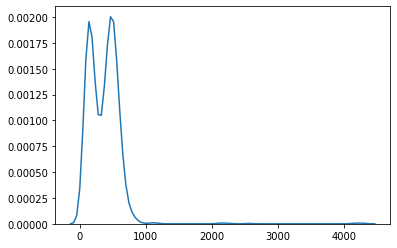

```python
wesfailed = mut.checkAmountOfSegments(segments,thresh = 2000)
wesfailed
```

```python
# reparing QC when we have a better duplicate
ref=pd.DataFrame(ccle_refsamples[ccle_refsamples.datatype=="wes"]['arxspan_id'])
replace={}
for val in wesfailed:
    if val in list(renaming.keys()):
        a = ref[ref.arxspan_id==ref.loc[val].arxspan_id].index
        for v in a:
            if v not in wesfailed:
                replace.update({val:v})
                break
print(len(replace), len(wesfailed))
for k, val in replace.items():
    renaming[val] = renaming.pop(k)
%store wesfailed
print("failed: ", wesfailed)
renaming.update(wes_toprefer)
torm=[]
for k, val in renaming.items():
    if val in wrongwes_arxspan:
        torm.append(k)
print('wrong wes:', torm)
for v in torm:
    renaming.pop(v)
```

[output not shown]

```python
segments = segments[~segments.DepMap_ID.isin(set(wesfailed)-set(wes_toprefer.keys()))].reset_index(drop=True)
genecn = genecn[~genecn.index.isin(set(wesfailed)-set(wes_toprefer.keys()))]
```

### QCing and saving replicate level data

```python
prevgenecn = (2**tc.get(name='depmap-a0ab', file='CCLE_gene_cn'))-1
prevsegments = tc.get(name='depmap-a0ab', file='CCLE_segment_cn')
prev = prevgenecn.index.tolist()
```

```
No dataset version provided. Using version 94.
```

```
[##################]100% |   2.2 MiB/s |  10.8 MiB /  10.8 MiB | Time:  0:00:04
```

```
No dataset version provided. Using version 94.
```

```python
ccle_refsamples[ccle_refsamples.arxspan_id=="ACH-002291"]
```

|  | arxspan_id | version | sm_id | PDO | datatype | size | ccle_name | stripped_cell_line_name | participant_id | cellosaurus_id | ... | 19q3 | 19q4 | 20q1 | 20q2 | 20q4 | 20q | 21Q1 | 21Q2 | low_quality | legacy_crc32_hash |
| --- | --- | --- | --- | --- | --- | --- | --- | --- | --- | --- | --- | --- | --- | --- | --- | --- | --- | --- | --- | --- | --- |
| CDS-pgDmZb | ACH-002291 | 1 | NaN | NaN | wes | 7.511130e+09 | NaN | NTERA2CLD1 | PT-L63btI6L | CVCL_3407 | ... | NaN | NaN | NaN | NaN | NaN | NaN | 0.0 | 1.0 | NaN | NaN |

1 rows × 55 columns

```python
ccle_refsamples[ccle_refsamples.arxspan_id=="ACH-001672"]
```

|  | arxspan_id | version | sm_id | PDO | datatype | size | ccle_name | stripped_cell_line_name | participant_id | cellosaurus_id | ... | 19q3 | 19q4 | 20q1 | 20q2 | 20q4 | 20q | 21Q1 | 21Q2 | low_quality | legacy_crc32_hash |
| --- | --- | --- | --- | --- | --- | --- | --- | --- | --- | --- | --- | --- | --- | --- | --- | --- | --- | --- | --- | --- | --- |
| CDS-Ckptje | ACH-001672 | 1 | NaN | NaN | wes | 1.321855e+10 | NaN | TERA2 | PT-L63btI6L | CVCL_2777 | ... | NaN | NaN | NaN | NaN | NaN | NaN | 1.0 | 1.0 | NaN | NaN |
| CDS-88fF3n | ACH-001672 | 1 | NaN | NaN | rna | 4.487903e+09 | NaN | TERA2 | PT-L63btI6L | CVCL_2777 | ... | 0.0 | 0.0 | 0.0 | 1.0 | NaN | NaN | 0.0 | NaN | 0.0 | NaN |

2 rows × 55 columns

```python
pd.concat([prevgenecn.loc[["ACH-002291"]], genecn.loc[['CDS-SyBYYw',"CDS-PavpH4"]])
```

```python
np.corrcoef(genecn.loc[['CDS-SyBYYw',"CDS-PavpH4", "CDS-l4hN5a"]])
```

```
array([[1.        , 0.10102085, 0.95199819],
       [0.10102085, 1.        , 0.11538706],
       [0.95199819, 0.11538706, 1.        ]])
```

```python
for v in set(segments.DepMap_ID):
    segments.loc[segments[segments.DepMap_ID==v].index,'Source']= ccle_refsamples[ccle_refsamples.index==v].source.values[0]

segments.Source = segments.Source.replace({'CCLF':'Broad WES', 'CHORDOMA':'Chordoma WES', 'SANGER':'Sanger WES', 'IBM':'Broad WES', np.nan:'Broad WES', 'DEPMAP':'Broad WES', 'IBM WES': "Broad WES", 'Broad CCLF':"Broad WES"})

segments.to_csv('temp/segments_allWES_withreplicates_'+samplesetname+'.csv', index=False)
genecn.to_csv('temp/gene_cn_allWES_withreplicates_'+samplesetname+".csv")
```

```python
segments = pd.read_csv('temp/segments_allWES_withreplicates_'+samplesetname+'.csv')
genecn = pd.read_csv('temp/gene_cn_allWES_withreplicates_'+samplesetname+".csv", index_col=0)
```

```python
# saving prioritized
wespriosegments = segments[segments.DepMap_ID.isin(set(renaming.keys()))].replace({'DepMap_ID': renaming}).reset_index(drop = True)
wespriogenecn = genecn[genecn.index.isin(set(renaming.keys()))].rename(index=renaming)
```

[output not shown]

```python
#ccle_refsamples = sheets.get(refsheet_url).sheets[0].to_frame(index_col=0)
#normals = ccle_refsamples[ccle_refsamples['primary_disease']=='normal'].index.tolist()
#wespriosegments = wespriosegments[~wespriosegments.DepMap_ID.isin(normals)]
#wespriogenecn = wespriogenecn.drop(index=normals)
```

```python
#h.compareDfs(priosegments, tc.get(name='depmap-a0ab', file='CCLE_segment_cn'))
h.compareDfs(wespriogenecn, tc.get(name='depmap-a0ab', file='CCLE_gene_cn'))
```

```
No dataset version provided. Using version 94.
FOUND missmatch Columns IN df1: set()
FOUND missmatch Columns NOT IN df1: set()
FOUND missmatch Index IN df1: {'ACH-002476', 'ACH-001760', 'ACH-001493', 'ACH-001449', 'ACH-001756', 'ACH-001210', 'ACH-001759', 'ACH-001293', 'ACH-001693', 'ACH-001434', 'ACH-001686', 'ACH-001662', 'ACH-001512', 'ACH-001708', 'ACH-001227', 'ACH-001349', 'ACH-001669', 'ACH-001438', 'ACH-001696', 'AC…
FOUND missmatch Index NOT IN df1: {'ACH-001037', 'ACH-001214', 'ACH-000982', 'ACH-000901', 'ACH-000854', 'ACH-001044', 'ACH-000229', 'ACH-001018', 'ACH-000526', 'ACH-000739', 'ACH-001225', 'ACH-000550', 'ACH-000710', 'ACH-000299', 'ACH-000632', 'ACH-001015', 'ACH-000842', 'ACH-002084', 'ACH-001042',…
FOUND new NAs in df1: -354
FOUND new 0s in df1: 0
```

```
(set(),
 set(),
 {'ACH-000010',
  'ACH-001210',
  'ACH-001227',
  'ACH-001293',
  'ACH-001349',
  'ACH-001434',
  'ACH-001437',
  'ACH-001438',
  'ACH-001449',
  'ACH-001493',
  'ACH-001502',
  'ACH-001512',
  'ACH-001537',
  'ACH-001662',
  'ACH-001669',
  'ACH-001672',
  'ACH-001676',
  'ACH-001686',
  'ACH-001693',
  'ACH-001696',
  'ACH-001708',
  'ACH-001756',
  'ACH-001758',
  'ACH-001759',
  'ACH-001760',
  'ACH-001854',
  'ACH-001855',
  'ACH-001971',
  'ACH-002138',
  'ACH-002392',
  'ACH-002476',
  'ACH-003210'},
 {'ACH-000003',
  'ACH-000014',
  'ACH-000016',
  'ACH-000034',
  'ACH-000044',
  'ACH-000049',
```

[output cut: 81 more lines]

```
  'ACH-001214',
  'ACH-001224',
  'ACH-001225',
  'ACH-001230',
  'ACH-001234',
  'ACH-001239',
  'ACH-001249',
  'ACH-001675',
  'ACH-001992',
  'ACH-002084',
  'ACH-002217',
  'ACH-002335',
  'ACH-002378'},
 -354,
 0)
```

```python
wespriosegments.to_csv("temp/segments_allWES_latest_"+samplesetname+".csv", index=False)
wespriogenecn.to_csv('temp/gene_cn_allWES_latest_'+samplesetname+".csv")
```

### Loading WGS

```python
res = refwm.get_sample_sets().loc["all"]
print(res)
wgssegments = res['combined_seg_file']
! gsutil cp $wgssegments "temp/segments_terra_merged_wgs.seg"
wgssegments = pd.read_csv('temp/segments_terra_merged_wgs.seg', sep='\t')
wgssegments = wgssegments.rename(columns={'CONTIG':'Chromosome',
'START':'Start',
'END':'End',
'Sample':"DepMap_ID",
'NUM_POINTS_COPY_RATIO':'Num_Probes',
'MEAN_LOG2_COPY_RATIO':'Segment_Mean',
'CALL':'Status'})
wgssegments['Source'] = "Broad WGS"
wgsrenaming = removeOlderVersions(names = set(wgssegments['DepMap_ID']), refsamples = ccle_refsamples[ccle_refsamples.datatype=="wgs"], arxspan_id = "arxspan_id", version="version")
wgssegments['Chromosome'] = [i[3:] for i in wgssegments['Chromosome'].tolist()]
wgssegments.Segment_Mean = 2**wgssegments.Segment_Mean
wgssegments.Start = wgssegments.Start.astype(int)
wgssegments.End = wgssegments.End.astype(int)
wgssegments.loc[wgssegments[wgssegments.Chromosome.isin(['X','Y'])].index,'Segment_Mean'] = wgssegments[wgssegments.Chromosome.isin(['X','Y'])]['Segment_Mean']/2
wgssegments = wgssegments.sort_values(by=['DepMap_ID','Chromosome','Start','End'])
len(set(wgssegments.DepMap_ID))
```

```
samples              [CDS-00Nrci, CDS-0b4jFH, CDS-0bV15m, CDS-0e3PR...
merged_vcf           gs://fc-secure-bd7b8bc9-f665-4269-997e-5a40208...
combined_seg_file    gs://fc-secure-bd7b8bc9-f665-4269-997e-5a40208...
Name: all, dtype: object
Copying gs://fc-secure-bd7b8bc9-f665-4269-997e-5a402088a369/bf211ba1-fe38-4a8a-b2d9-d26b44af2048/aggregate_CN_segments_wrkflw/970966c5-23b3-4a7d-98a9-3530ed41062c/call-aggregate_CN_segments/all.called.seg...
/ [1 files][ 16.6 MiB/ 16.6 MiB]
Operation completed over 1 objects/16.6 MiB.
removed 2 duplicate samples
```

```
468
```

```python
wgsrenaming = tracker.removeOlderVersions(names = set(wgssegments['DepMap_ID'])-{'CDS-R22IHj'}, refsamples = ccle_refsamples[ccle_refsamples.datatype=="wgs"], arxspan_id = "arxspan_id", version="version")
```

```
removed 1 duplicate samples
```

```python
wgssegments.Segment_Mean.min(), wespriosegments.Segment_Mean.min()
```

```
(4.90354135032729e-11, 1.9138595346232107e-10)
```

```python
gapmergedsegs = mut.manageGapsInSegments(wgssegments)
wgsgenecn = mut.toGeneMatrix(gapmergedsegs, gene_mapping)
print(wgsgenecn.values.min(), wgsgenecn.values.mean(), wgsgenecn.values.max())
mut.checkGeneChangeAccrossAll(wgsgenecn, thresh=0.025)
```

```
6.016681732310223e-11 1.0665836510796856 880.3157246599864
```

```
[]
```

```python
wgsfailed = ['CDS-mYOC4j', 'CDS-Wszh2o', 'CDS-3PGQ84']
```

```
CDS-mYOC4j 3963
CDS-Wszh2o 3301
CDS-3PGQ84 5505
```

```
['CDS-mYOC4j', 'CDS-Wszh2o', 'CDS-3PGQ84']
```

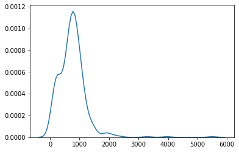

```python
wgsfailed = mut.checkAmountOfSegments(wgssegments,thresh = 3000)
wgsfailed
```

```python
# reparing QC when we have a better duplicate
ref=pd.DataFrame(ccle_refsamples[ccle_refsamples.datatype=="wgs"]['arxspan_id'])
replace={}
for val in wgsfailed:
    if val in list(wgsrenaming.keys()):
        a = ref[ref.arxspan_id==ref.loc[val].arxspan_id].index
        for v in a:
            if v not in wgsfailed:
                replace.update({val:v})
                break
print(len(replace))
for k, val in replace.items():
    wgsrenaming[val] = wgsrenaming.pop(k)
%store wgsfailed
wgsfailed
```

```
0
Stored 'wgsfailed' (list)
```

```
['CDS-mYOC4j', 'CDS-Wszh2o', 'CDS-3PGQ84']
```

```python
# plotting results of CN calls for this new sample set
for i, (k, val) in enumerate(refwm.get_samples().loc[refwm.get_sample_sets().loc[samplesetname].samples].iterrows()):
    plot = val["modeled_segments_plot_tumor"]
    ! gsutil cp $plot temp/
    print(k)
    print(val['arxspan_id'], val['sex'])
    if i>30:
        continue
    display(Image('temp/'+plot.split('/')[-1]))
```

[output not shown]

### Saving and merging CN

```python
#removing failed samples
wgssegments = wgssegments[~wgssegments.DepMap_ID.isin(wgsfailed)].reset_index(drop=True)
wgsgenecn = wgsgenecn[~wgsgenecn.index.isin(wgsfailed)]
wgssegments.to_csv('temp/segments_allWGS_withreplicates_'+samplesetname+'.csv', index=False)
wgsgenecn.to_csv('temp/gene_cn_allWGS_withreplicates_'+samplesetname+".csv")
```

```python
wgssegments = pd.read_csv('temp/segments_allWGS_withreplicates_'+samplesetname+'.csv')
wgsgenecn = pd.read_csv('temp/gene_cn_allWGS_withreplicates_'+samplesetname+".csv", index_col=0)
```

```python
wgspriosegments = wgssegments[wgssegments.DepMap_ID.isin(set(wgsrenaming.keys()))].replace({'DepMap_ID':wgsrenaming}).reset_index(drop=True)
wgspriogenecn = wgsgenecn[wgsgenecn.index.isin(set(wgsrenaming.keys()))].rename(index=wgsrenaming)
wgspriosegments.to_csv("temp/segments_allWGS_latest_"+samplesetname+".csv", index=False)
wgspriogenecn.to_csv('temp/gene_cn_allWGS_latest_'+samplesetname+".csv")
```

### Comparison and merging with WES

```python
ind = set(wespriogenecn.index) & set(wgspriogenecn.index)
cols = set(wespriogenecn.columns) & set(wgspriogenecn.columns)
ge = np.log2(1+wespriogenecn[cols])
ce = np.log2(1+wgspriogenecn[cols])
corr={}
for val in ind:
    corr[val] = pearsonr(ge.loc[val],ce.loc[val])[0]
```

```
ACH-000511
{'Broad WGS'} {'Broad WES'}
ACH-000278
{'Broad WGS'} {'Broad WES'}
ACH-000961
{'Broad WGS'} {'Sanger WES'}
ACH-000271
{'Broad WGS'} {'Broad WES'}
ACH-000856
{'Broad WGS'} {'Sanger WES'}
```

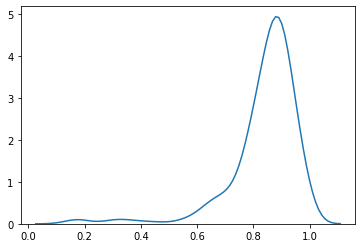

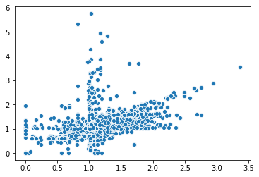

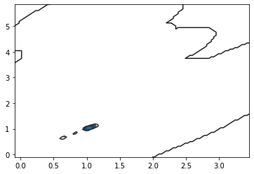

```python
for k,v in corr.items():
    if v<0.5:
        print(k)
        print(set(wgspriosegments[wgspriosegments.DepMap_ID==k].Source), set(wespriosegments[wespriosegments.DepMap_ID==k].Source))

a = np.array(list(corr.values()))
sns.kdeplot(a)
plt.show()
sns.scatterplot(x=ge.loc[ind].values.ravel()[:100000],y=ce.loc[ind].values.ravel()[:100000],)
plt.show()
sns.kdeplot(data=np.array([ge.loc[ind].values.ravel()[:100000], ce.loc[ind].values.ravel()[:100000]]).T, fill=True)
plt.show()
```

```python
#h.compareDfs(priosegments, tc.get(name='depmap-a0ab', file='CCLE_segment_cn'))
h.compareDfs(wgspriogenecn, tc.get(name='depmap-a0ab', file='CCLE_gene_cn'))
```

```python
mergedsegments =  wgspriosegments.append(wespriosegments[~wespriosegments.DepMap_ID.isin(set(wgspriosegments.DepMap_ID))])[['DepMap_ID', 'Chromosome', 'Start', 'End', 'Segment_Mean', 'Num_Probes', 'Status', 'Source']]
mergedgenecn =  wgspriogenecn.append(wespriogenecn[~wespriogenecn.index.isin(set(wgspriogenecn.index))])

mergedgenecn.to_csv('temp/gene_cn_all_merged_'+samplesetname+".csv")
mergedsegments.to_csv('temp/segments_all_merged_'+samplesetname+".csv",index=False)
```

```python
#adding to the sample tracker the sequencing that were selected and the ones that failed QC
ccle_refsamples = sheets.get(refsheet_url).sheets[0].to_frame(index_col=0)
ccle_refsamples.loc[ccle_refsamples[ccle_refsamples.datatype.isin(['wes',"wgs"])].index, samplesetname]=0
selected = {j:i for i,j in renaming.items()}
selected.update({j:i for i,j in wgsrenaming.items()})
len(selected)
ccle_refsamples.loc[selected.values(),samplesetname]=1
ccle_refsamples.loc[list(wesfailed)+list(wgsfailed),'low_quality']=1
dfToSheet(ccle_refsamples,'ccle sample tracker', secret=creds)
```

## postprocessing Mutations

First we need to do an additional step of filtering on coverage and number

- readMutations
- createSNPs
- addToMainMutation
- filterAllelicFraction
- filterMinCoverage
- mergeAnnotations
- addAnnotation
- maf_add_variant_annotations
- mutation_maf_to_binary_matrix (x3)

```python
wesres = dm.WorkspaceManager(wesmutworkspace)
```

### WES Somatic

```python
wesres.update_sample_set('all', wesres.get_samples().index.tolist())
```

```
Successfully imported 1 sample sets:
  * all (1969 samples)
```

```python
filtered = wesres.get_sample_sets().loc['all','filtered_CGA_MAF_aggregated']
! gsutil cp $filtered "temp/mutation_filtered_terra_merged.txt"
mutations = pd.read_csv('temp/mutation_filtered_terra_merged.txt',sep='\t')
print(mutations.columns[:10])
mutations = mutations.rename(columns={"i_ExAC_AF":"ExAC_AF","Tumor_Sample_Barcode":'DepMap_ID',"Tumor_Seq_Allele2":"Tumor_Allele"}).drop(columns=['Center','Tumor_Seq_Allele1'])
mutations['CGA_WES_AC'] = [str(i[0]) + ':' + str(i[1]) for i in np.nan_to_num(mutations[['t_alt_count','t_ref_count']].values,0).astype(int)]
mutations = mutations[~mutations['DepMap_ID'].isin(wrong|deletedwes)]
#renaming = tracker.removeOlderVersions(names = set(mutations['DepMap_ID']), refsamples = wescgawm.get_samples(), arxspan_id = "arxspan_id", version="version")
```

[output not shown]

```python
mutations = mut.filterCoverage(mutations, loc=['CGA_WES_AC'], sep=':',cov=2)
mutations = mut.filterAllelicFraction(mutations, loc=['CGA_WES_AC'], sep=':',frac=0.1)
mutations = omics_mut.addAnnotation(mutations, NCBI_Build='37', Strand="+")
mutations = omics_mut.annotateLikelyImmortalized(mutations, TCGAlocs = ['TCGAhsCnt',
'COSMIChsCnt'], max_recurrence=0.05 ,min_tcga_true_cancer=5)
mutations.to_csv('temp/wes_somatic_mutations_withduplicates_'+samplesetname+'.csv', index=False)
```

```python
mutations = pd.read_csv('temp/wes_somatic_mutations_withduplicates_'+samplesetname+'.csv')
```

```python
#TODO: Count the total number of mutations per cell line, split by type (SNP, INS, DEL)
#TODO: Count the total number of mutations observed by position
```

```python
%store -r failed
failed
```

```
{'CDS-H8AM79', 'CDS-Qcyabl', 'CDS-Rl87Z1', 'CDS-TzQAjG', 'CDS-mys9Dm'}
```

```python
# based on QC from the CN pipeline:
#TODO: in the future merge QC results from mutations/ remapping & CN to filter wrong
priomutations = mutations[mutations.DepMap_ID.isin(renaming.keys())].replace({'DepMap_ID':renaming})
```

### WGS Somatic

```python
res = cgawm.get_sample_sets().loc["allcurrent"]
filtered = res['filtered_CGA_MAF_aggregated']
! gsutil cp $filtered "temp/mutation_filtered_terra_merged_wgs.txt"
wgsmutations = pd.read_csv('temp/mutation_filtered_terra_merged_wgs.txt',sep='\t')
print(wgsmutations.columns[:10])
wgsmutations = wgsmutations.rename(columns={"i_ExAC_AF":"ExAC_AF","Tumor_Sample_Barcode":'DepMap_ID',"Tumor_Seq_Allele2":"Tumor_Allele"}).drop(columns=['Center','Tumor_Seq_Allele1'])
wgsmutations = omics_mut.annotateLikelyImmortalized(wgsmutations, TCGAlocs = ['TCGAhsCnt', 'COSMIChsCnt'], max_recurrence=0.05 ,min_tcga_true_cancer=5)

wgsmutations['CGA_WES_AC'] = [str(i[0]) + ':' + str(i[1]) for i in np.nan_to_num(wgsmutations[['t_alt_count','t_ref_count']].values,0).astype(int)]

wgsmutations = mut.filterCoverage(wgsmutations, loc=['CGA_WES_AC'], sep=':',cov=2)
wgsmutations = mut.filterAllelicFraction(wgsmutations, loc=['CGA_WES_AC'], sep=':',frac=0.1)
wgsmutations = omics_mut.addAnnotation(wgsmutations, NCBI_Build='37', Strand="+")

wgsmutations = wgsmutations[wgsmutations.DepMap_ID.isin(wgsrenaming.keys())].replace({'DepMap_ID':wgsrenaming})

wgsmutations.to_csv('temp/wgs_somatic_mutations_'+samplesetname+'.csv',index=None)
```

```python
h.dups(priomutations.Genome_Change+priomutations.DepMap_ID)
```

```
[]
```

```python
wgsmutations = pd.read_csv('temp/wgs_somatic_mutations_'+samplesetname+'.csv')
```

### Merge [WES / WGS exonic] somatic

```python
toadd = set(wgsmutations.DepMap_ID) - set(priomutations.DepMap_ID)
priomutations = priomutations.append(wgsmutations[wgsmutations.DepMap_ID.isin(toadd)]).reset_index(drop = True)
#normals = set(ccle_refsamples[ccle_refsamples.primary_disease=="normal"].arxspan_id)
#mutations = mutations[~mutations.DepMap_ID.isin(normals)]
priomutations.to_csv('temp/wes_somatic_mutations_all_'+samplesetname+'.csv', index=False)
```

```python
priomutations = pd.read_csv('temp/wes_somatic_mutations_all_'+samplesetname+'.csv')
```

### making mutations matrices

```python
# binary mutations matrices
mut.mafToMat(priomutations[(priomutations.isDeleterious) ]).astype(int).T.to_csv('temp/wes_somatic_mutations_deleterious_boolmatrix.csv')
mut.mafToMat(priomutations[~(priomutations.isDeleterious | priomutations.isCOSMIChotspot | priomutations.isTCGAhotspot | priomutations['Variant_Classification']=='Silent') ]).astype(int).T.to_csv('temp/wes_somatic_mutations_other_boolmatrix.csv')
mut.mafToMat(priomutations[(priomutations.isCOSMIChotspot | priomutations.isTCGAhotspot)]).astype(int).T.to_csv('temp/wes_somatic_mutations_hotspot_boolmatrix.csv')
```

```
100%
```

```python
# genotyped mutations matrices
mut.mafToMat(priomutations[(priomutations.isDeleterious)], mode="genotype", minfreqtocall=0.05).T.to_csv('temp/wes_somatic_mutations_deleterious_matrix.csv')
mut.mafToMat(priomutations[~(priomutations.isDeleterious | priomutations.isCOSMIChotspot | priomutations.isTCGAhotspot | priomutations['Variant_Classification']=='Silent')], mode="genotype", minfreqtocall=0.05).T.to_csv('temp/wes_somatic_mutations_other_matrix.csv')
mut.mafToMat(priomutations[(priomutations.isCOSMIChotspot | priomutations.isTCGAhotspot)], mode="genotype", minfreqtocall=0.05).T.to_csv('temp/wes_somatic_mutations_hotspot_matrix.csv')
```

```
100%
```

### adding legacy datasets

```python
legacy_hybridcapture = tc.get(name='mutations-da6a', file='legacy_hybridcapture_somatic_mutations').drop(columns=['Unnamed: 0',"Tumor_Sample_Barcode"]).rename(columns={'Tumor_Seq_Allele1':'Tumor_Allele'})
legacy_raindance = tc.get(name='mutations-da6a', file='legacy_raindance_somatic_mutations').drop(columns=['Unnamed: 0',"Tumor_Sample_Barcode"]).rename(columns={'Tumor_Seq_Allele1':'Tumor_Allele'})
legacy_rna = tc.get(name='mutations-da6a', file='legacy_rna_somatic_mutations').drop(columns=['Unnamed: 0',"Tumor_Sample_Barcode"]).rename(columns={'Tumor_Seq_Allele1':'Tumor_Allele'})
legacy_wes_sanger = tc.get(name='mutations-da6a', file='legacy_wes_sanger_somatic_mutations').drop(columns=['Unnamed: 0',"Tumor_Sample_Barcode"]).rename(columns={'Tumor_Seq_Allele1':'Tumor_Allele'})
legacy_wgs_exoniconly = tc.get(name='mutations-da6a', file='legacy_wgs_exoniconly_somatic_mutations').drop(columns=['Unnamed: 0',"Tumor_Sample_Barcode"]).rename(columns={'Tumor_Seq_Allele1':'Tumor_Allele'})
```

```
No dataset version provided. Using version 1.
No dataset version provided. Using version 1.
No dataset version provided. Using version 1.
No dataset version provided. Using version 1.
No dataset version provided. Using version 1.
```

### solving issues with the legacy datasets

```python
legacy_wgs_exoniconly.loc[legacy_wgs_exoniconly[legacy_wgs_exoniconly['Genome_Change'].isna()].index, 'Genome_Change'] = ['g.chr'+str(i.Chromosome)+":"+str(i.Start_position)+i.Reference_Allele+">"+i.Tumor_Allele for _, i in legacy_wgs_exoniconly[legacy_wgs_exoniconly['Genome_Change'].isna()].iterrows()]
legacy_wgs_exoniconly['t_alt_count'] = legacy_wgs_exoniconly.WGS_AC.str.split(':').str[0].astype(int)
legacy_wgs_exoniconly['t_ref_count'] = legacy_wgs_exoniconly.WGS_AC.str.split(':').str[1].astype(int)
legacy_wgs_exoniconly['tumor_f'] = legacy_wgs_exoniconly['t_alt_count'] / (legacy_wgs_exoniconly['t_ref_count'] + legacy_wgs_exoniconly['t_alt_count'])
```

```python
legacy_wes_sanger.loc[legacy_wes_sanger[legacy_wes_sanger['Genome_Change'].isna()].index, 'Genome_Change'] = ['g.chr'+str(i.Chromosome)+":"+str(i.Start_position)+i.Reference_Allele+">"+i.Tumor_Allele for _, i in legacy_wes_sanger[legacy_wes_sanger['Genome_Change'].isna()].iterrows()]
legacy_wes_sanger['t_alt_count'] = legacy_wes_sanger.SangerWES_AC.str.split(':').str[0].astype(int)
legacy_wes_sanger['t_ref_count'] = legacy_wes_sanger.SangerWES_AC.str.split(':').str[1].astype(int)
legacy_wes_sanger['tumor_f'] = legacy_wes_sanger['t_alt_count'] / (legacy_wes_sanger['t_ref_count'] + legacy_wes_sanger['t_alt_count'])
```

```python
legacy_raindance.loc[legacy_raindance[legacy_raindance['Genome_Change'].isna()].index, 'Genome_Change'] = ['g.chr'+str(i.Chromosome)+":"+str(i.Start_position)+i.Reference_Allele+">"+i.Tumor_Allele for _, i in legacy_raindance[legacy_raindance['Genome_Change'].isna()].iterrows()]
legacy_raindance['t_alt_count'] = legacy_raindance.RD_AC.str.split(':').str[0].astype(int)
legacy_raindance['t_ref_count'] = legacy_raindance.RD_AC.str.split(':').str[1].astype(int)
legacy_raindance['tumor_f'] = legacy_raindance['t_alt_count'] / (legacy_raindance['t_ref_count'] + legacy_raindance['t_alt_count'])
```

```python
legacy_hybridcapture.loc[legacy_hybridcapture[legacy_hybridcapture['Variant_Classification'].isna()].index,'Variant_Classification']='Missense_Mutation'
legacy_hybridcapture.loc[legacy_hybridcapture[legacy_hybridcapture['Genome_Change'].isna()].index, 'Genome_Change'] = ['g.chr'+str(i.Chromosome)+":"+str(i.Start_position)+i.Reference_Allele+">"+i.Tumor_Allele for _, i in legacy_hybridcapture[legacy_hybridcapture['Genome_Change'].isna()].iterrows()]
legacy_hybridcapture['t_alt_count'] = legacy_hybridcapture.HC_AC.str.split(':').str[0].astype(int)
legacy_hybridcapture['t_ref_count'] = legacy_hybridcapture.HC_AC.str.split(':').str[1].astype(int)
legacy_hybridcapture['tumor_f'] = legacy_hybridcapture['t_alt_count'] / (legacy_hybridcapture['t_ref_count'] + legacy_hybridcapture['t_alt_count'])
```

```python
legacy_rna.loc[legacy_rna[legacy_rna['Genome_Change'].isna()].index, 'Genome_Change'] = ['g.chr'+str(i.Chromosome)+":"+str(i.Start_position)+i.Reference_Allele+">"+i.Tumor_Allele for _, i in legacy_rna[legacy_rna['Genome_Change'].isna()].iterrows()]
legacy_rna['t_alt_count'] = legacy_rna.RNAseq_AC.str.split(':').str[0].astype(int)
legacy_rna['t_ref_count'] = legacy_rna.RNAseq_AC.str.split(':').str[1].astype(int)
legacy_rna['tumor_f'] = legacy_rna['t_alt_count'] / (legacy_rna['t_ref_count'] + legacy_rna['t_alt_count'])
```

```python
todrop = []
legacy_rna['loci'] = legacy_rna['DepMap_ID']+"_"+legacy_rna['Chromosome']+"_"+legacy_rna['Start_position'].astype(str)
for val in h.dups(legacy_rna.loci):
    todrop.append(legacy_rna[legacy_rna.loci==val].index[0])
legacy_rna = legacy_rna.drop(todrop)
```

```python
#legacy_hybridcapture = legacy_hybridcapture[~legacy_hybridcapture.DepMap_ID.isin(normals)]
#legacy_raindance = legacy_raindance[~legacy_raindance.DepMap_ID.isin(normals)]
#legacy_wes_sanger = legacy_wes_sanger[~legacy_wes_sanger.DepMap_ID.isin(normals)]
```

```python
legacy_wgs_exoniconly = legacy_wgs_exoniconly[~legacy_wgs_exoniconly.DepMap_ID.isin(wrongwes_arxspan)]
legacy_wes_sanger = legacy_wes_sanger[~legacy_wes_sanger.DepMap_ID.isin(wrongwes_arxspan)]
legacy_raindance = legacy_raindance[~legacy_raindance.DepMap_ID.isin(wrongwes_arxspan)]
legacy_rna = legacy_rna[~legacy_rna.DepMap_ID.isin(wrongwes_arxspan)]
legacy_hybridcapture = legacy_hybridcapture[~legacy_hybridcapture.DepMap_ID.isin(set(wrongwes_arxspan)-set(tokeep_specific_hybrid_capture))]
```

```python
merged = mut.mergeAnnotations(priomutations, legacy_hybridcapture, "HC_AC", useSecondForConflict=True, dry_run=False)
merged = mut.mergeAnnotations(merged, legacy_raindance, "RD_AC", useSecondForConflict=True, dry_run=False)
merged = mut.mergeAnnotations(merged, legacy_wgs_exoniconly, "WGS_AC", useSecondForConflict=False, dry_run=False)
merged = mut.mergeAnnotations(merged, legacy_wes_sanger, "SangerWES_AC", useSecondForConflict=False, dry_run=False)
merged = mut.mergeAnnotations(merged, legacy_rna, "RNAseq_AC", useSecondForConflict=False, dry_run=False)
```

```
found 464 nonmatching mutations
found 3 nonmatching mutations
found 177 nonmatching mutations
found 248 nonmatching mutations
found 298 nonmatching mutations
```

```python
merged = merged[merged['tumor_f']>0.05]
```

```python
merged = omics_mut.annotateLikelyImmortalized(merged, TCGAlocs = ['TCGAhsCnt', 'COSMIChsCnt'], max_recurrence=0.05 ,min_tcga_true_cancer=5)
```

### changing variant annotations

```python
mutation_groups={
"other conserving": ["5'Flank", "Intron", "IGR", "3'UTR", "5'UTR"],
"other non-conserving":["In_Frame_Del", "In_Frame_Ins", "Stop_Codon_Del", "Stop_Codon_Ins", "Missense_Mutation", "Nonstop_Mutation"],
'silent': ['Silent'],
"damaging":['De_novo_Start_OutOfFrame','Frame_Shift_Del','Frame_Shift_Ins', 'Splice_Site', 'Start_Codon_Del', 'Start_Codon_Ins', 'Start_Codon_SNP','Nonsense_Mutation']
}
```

```python
rename = {}
for k,v in mutation_groups.items():
    for e in v:
        rename[e] = k
merged['Variant_annotation'] = [rename[i] for i in merged['Variant_Classification'].tolist()]
```

### Compare to previous release

I would run some checks here comparing the results to the previous releases MAF. Namely:

- Count the total number of mutations per cell line, split by type (SNP, INS, DEL)
- Count the total number of mutations observed by position (group by chromosome, start position, end position and count the number of mutations)
- Look at specific differences between the two MAFs (join on DepMap_ID, Chromosome, Start position, End position, Variant_Type). I would do this for WES only

```python
a = set(merged.DepMap_ID)
prev = tc.get(name='depmap-a0ab', file='CCLE_mutations')#tc.get(name='internal-20q2-7f46', version=18, file='CCLE_mutations')
b = set(prev.DepMap_ID)
print("new lines:")
print(a-b)
print('lost lines:')
print(b-a)
```

```
No dataset version provided. Using version 95.
new lines:
{'ACH-001697', 'ACH-002669', 'ACH-001683', 'ACH-001571', 'ACH-002680', 'ACH-002785', 'ACH-002138', 'ACH-001393', 'ACH-001553', 'ACH-001976', 'ACH-002544', 'ACH-002034', 'ACH-001817', 'ACH-001447', 'ACH-001445', 'ACH-002061', 'ACH-001760', 'ACH-001759', 'ACH-002828', 'ACH-002359', 'ACH-001988', 'ACH-…
lost lines:
{'ACH-002010'}
```

```python
set(mutations[mutations.DepMap_ID.isin(e.keys())].replace({'DepMap_ID':e}).DepMap_ID)
```

```
{'ACH-001955', 'ACH-001956', 'ACH-001957'}
```

```python
e = {"CDS-mys9Dm":"ACH-001955",
"CDS-Rl87Z1":"ACH-001956",
"CDS-TzQAjG":"ACH-001957"}
```

```python
merged = merged.append(mutations[mutations.DepMap_ID.isin(e.keys())].replace({'DepMap_ID':e}))
```

### check important mutations

```python
# check MOLM13, MV411 cell lines- The well known mutation status of FLT3
```

```python
# check TP53 mutation
```

Are mutation consistent?

QC mutations, for a known dependency, check if it matches mutation of this gene. (if P53 is mutated, cannot have dependency on P53 or MDM2 MDM4/ inverse fir BRAF and KRAF to themselves)

### saving this version

```python
merged.to_csv('temp/all_somatic_mutations_withlegacy_'+samplesetname+'.csv', index=False)
```

```python
merged = pd.read_csv('temp/all_somatic_mutations_withlegacy_'+samplesetname+'.csv')
```

### making binary matrices

```python
merged['mutname'] = merged['Hugo_Symbol'] + " (" + merged["Entrez_Gene_Id"].astype(str) + ")"
merged = merged[merged['Entrez_Gene_Id']!=0]

# removing immortalized ffor now
merged = merged[merged.is_likely_immortalization!=True]
```

```python
mut.mafToMat(merged[(merged.Variant_annotation=="damaging")], mode='bool', mutNameCol="mutname").astype(int).T.to_csv('temp/all_somatic_mutations_boolmatrix_fordepmap_damaging.csv')
mut.mafToMat(merged[(merged.Variant_annotation=="other conserving")], mode='bool', mutNameCol="mutname").astype(int).T.to_csv('temp/all_somatic_mutations_boolmatrix_fordepmap_othercons.csv')
mut.mafToMat(merged[(merged.Variant_annotation=="other non-conserving")], mode='bool', mutNameCol="mutname").astype(int).T.to_csv('temp/all_somatic_mutations_boolmatrix_fordepmap_othernoncons.csv')
mut.mafToMat(merged[(merged.isCOSMIChotspot | merged.isTCGAhotspot)], mode='bool', mutNameCol="mutname").astype(int).T.to_csv('temp/all_somatic_mutations_boolmatrix_fordepmap_hotspot.csv')
```

```
100%
```

### retrieving unfiltered mutations [OPTIONAL]

```python
####### WES
unfiltered = wesres['unfiltered_CGA_MAF_aggregated']
! gsutil cp $unfiltered "temp/wes_mutation_unfiltered_terra_merged.txt"
unfiltered = pd.read_csv('temp/wes_mutation_unfiltered_terra_merged.txt', sep='\t', encoding='L6',na_values=["__UNKNOWN__",'.'], engine='c', dtype=str)
```

```python
unfiltered['somatic'] = unfiltered['somatic'].replace('nan','False')
unfiltered['HGNC_Status'] = unfiltered['HGNC_Status'].replace('nan','Unapproved')
unfiltered['judgement'] = unfiltered['judgement'].replace('nan','REMOVE')
unfiltered = unfiltered.rename(columns={"i_ExAC_AF":"ExAC_AF","Tumor_Sample_Barcode":'DepMap_ID',"Tumor_Seq_Allele2":"Tumor_Allele"}).drop(columns=['Tumor_Seq_Allele1'])
unfiltered['CGA_WES_AC'] = [str(i[0]) + ':' + str(i[1]) for i in np.nan_to_num(unfiltered[['t_alt_count','t_ref_count']].values.astype(float),0).astype(int)]
```

```python
toremove = []
subunfilt = unfiltered.iloc[:10000]
for i, val in enumerate(unfiltered.columns):
    h.showcount(i,len(unfiltered.columns))
    if len(set(subunfilt[val])-set(['nan']))==1:
        if len(set(unfiltered[val])-set(['nan']))==1:
            toremove.append(val)
unfiltered = unfiltered.drop(columns=set(toremove))
```

```python
ls temp/*_mutation_somatic_unfiltered_withreplicates.csv*
```

```
temp/wes_mutation_somatic_unfiltered_withreplicates.csv
```

```python
toint =  ["Start_position", "End_position"]
for val in toint:
    unfiltered[val]  = unfiltered[val].astype(int)
unfiltered.to_csv('temp/wes_mutation_somatic_unfiltered_withreplicates.csv.gz', index=False)
```

```python
del unfiltered
```

```python
####### WGS
unfiltered = res['unfiltered_CGA_MAF_aggregated']
! gsutil cp $unfiltered "temp/wes_mutation_unfiltered_terra_merged.txt"
unfiltered = pd.read_csv('temp/wes_mutation_unfiltered_terra_merged.txt', sep='\t', encoding='L6',na_values=["__UNKNOWN__",'.'], engine='c', dtype=str)
```

```python
unfiltered['somatic'] = unfiltered['somatic'].replace('nan','False')
unfiltered['HGNC_Status'] = unfiltered['HGNC_Status'].replace('nan','Unapproved')
unfiltered['judgement'] = unfiltered['judgement'].replace('nan','REMOVE')
unfiltered = unfiltered.rename(columns={"i_ExAC_AF":"ExAC_AF","Tumor_Sample_Barcode":'DepMap_ID',"Tumor_Seq_Allele2":"Tumor_Allele"}).drop(columns=['Tumor_Seq_Allele1'])
unfiltered['CGA_WES_AC'] = [str(i[0]) + ':' + str(i[1]) for i in np.nan_to_num(unfiltered[['t_alt_count','t_ref_count']].values.astype(float),0).astype(int)]
```

```python
toremove = []
subunfilt = unfiltered.iloc[:10000]
for i, val in enumerate(unfiltered.columns):
    h.showcount(i,len(unfiltered.columns))
    if len(set(subunfilt[val])-set(['nan']))==1:
        if len(set(unfiltered[val])-set(['nan']))==1:
            toremove.append(val)
unfiltered = unfiltered.drop(columns=set(toremove))
```

```python
toint =  ["Start_position", "End_position"]
for val in toint:
    unfiltered[val]  = unfiltered[val].astype(int)
unfiltered.to_csv('temp/wgs_mutation_somatic_unfiltered_withreplicates.csv.gz', index=False)
```

```python
del unfiltered
```

# uploading on taiga [CCLE ONLY]

## Somatic mutations

```python
#reverting to previous versions
merged = merged[['Hugo_Symbol', 'Entrez_Gene_Id', 'NCBI_Build', 'Chromosome',
       'Start_position', 'End_position', 'Strand', 'Variant_Classification',
       'Variant_Type', 'Reference_Allele', 'Tumor_Allele', 'dbSNP_RS',
       'dbSNP_Val_Status', 'Genome_Change', 'Annotation_Transcript',
       'DepMap_ID', 'cDNA_Change', 'Codon_Change', 'Protein_Change', 'isDeleterious',
       'isTCGAhotspot', 'TCGAhsCnt', 'isCOSMIChotspot', 'COSMIChsCnt',
       'ExAC_AF',"Variant_annotation", 'CGA_WES_AC', 'HC_AC',
       'RD_AC', 'RNAseq_AC', 'SangerWES_AC', 'WGS_AC']].rename(columns={"Tumor_Allele":"Tumor_Seq_Allele1"})
merged.to_csv('temp/all_somatic_mutations_withlegacy_'+samplesetname+"_depmapversion.csv", index=False)
```

```python
!gunzip temp/wes_mutation_somatic_unfiltered_withreplicates.csv.gz
!gunzip temp/wgs_mutation_somatic_unfiltered_withreplicates.csv.gz
```

```python
a = 'temp/expression_' + samplesetname + '_transcripts_tpm_logp1.csv'
! ls -al $a
```

```
-rw-r--r-- 1 jeremie jeremie 3433958665 Apr 14 21:02 temp/expression_21Q2_transcripts_tpm_logp1.csv
```

```python
tc.update_dataset(changes_description="new "+samplesetname+" release!",
                 dataset_permaname="mutations-latest-ed72",
                 upload_files=[
                    {
                       "path": "temp/all_somatic_mutations_boolmatrix_fordepmap_hotspot.csv",
                       "name": "all_somatic_mutations_boolmatrix_fordepmap_hotspot",
                       "format": "NumericMatrixCSV",
                       "encoding": "utf-8"
                    },
                    {
                       "path": "temp/all_somatic_mutations_boolmatrix_fordepmap_othernoncons.csv",
                       "name": "all_somatic_mutations_boolmatrix_fordepmap_othernoncons",
                       "format": "NumericMatrixCSV",
                       "encoding": "utf-8"
                    },
                    {
                        "path": "temp/all_somatic_mutations_boolmatrix_fordepmap_damaging.csv",
                        "name": "all_somatic_mutations_boolmatrix_fordepmap_damaging",
                        "format": "NumericMatrixCSV",
                        "encoding": "utf-8"
                    },
                    {
                        "path": "temp/all_somatic_mutations_withlegacy_"+samplesetname+"_depmapversion.csv",
                        "name": 'all_somatic_mutations_all_'+samplesetname+"_depmapversion",
                        "format": "TableCSV",
                        "encoding": "utf-8"
                    },
                    {
                        "path": "temp/all_somatic_mutations_withlegacy_"+samplesetname+".csv",
                        "name": 'all_somatic_mutations_all_'+samplesetname,
                        "format": "TableCSV",
                        "encoding": "utf-8"
                    },
                 ],
                 add_all_existing_files=True,
                  upload_async=False,
                 dataset_description="""
# Mutations

PORTAL TEAM SHOULD NOT USE THIS: There are lines here that should not make it even to internal.

/!\ This is the most up to date version of the CCLE Mutatios data.
The data is most likely of a better quality that what is on other folder. It is however in beta version as not all changes have either been confirmed or accepted by the DepMap Ops and the DepMap Portal Team.

# Notations:

all: every cell lines we have

WES: all data comes from the WExomeS samples we posses

WGS: all data comes from the WGenomeS samples we posses

withreplicates: if we have two different sequencing from a sample, we kept both, see the depmap sample tracker for annotations [https://docs.google.com/spreadsheets/d/1XkZypRuOEXzNLxVk9EOHeWRE98Z8_DBvL4PovyM01FE](https://docs.google.com/spreadsheets/d/1XkZypRuOEXzNLxVk9EOHeWRE98Z8_DBvL4PovyM01FE). this dataset is more geared toward QC or in-depth analysis of a particular cell line.

merged: everything from both WGS and WES

latest: only the latest sequencing versions of the samples were kept

genes (gene rpkm):
__Rows__:
__Columns__:
Counts (gene counts):
__Rows__:
__Columns__:
Gene level CN data:
__Rows__:
__Columns__:
 DepMap cell line IDs
 gene names in the format HGNC\_symbol (Entrez\_ID)
DepMap\_ID, Chromosome, Start, End, Num\_Probes, Segment\_Mean
 """)
```

```
No dataset version provided. Using version 13.
Finished uploading all_somatic_mutations_boolmatrix_fordepmap_hotspot to S3
Uploading all_somatic_mutations_boolmatrix_fordepmap_hotspot to Taiga
Finished uploading all_somatic_mutations_boolmatrix_fordepmap_hotspot to Taiga
Finished uploading all_somatic_mutations_boolmatrix_fordepmap_othernoncons to S3
Uploading all_somatic_mutations_boolmatrix_fordepmap_othernoncons to Taiga
Finished uploading all_somatic_mutations_boolmatrix_fordepmap_othernoncons to Taiga
Finished uploading all_somatic_mutations_boolmatrix_fordepmap_damaging to S3
Uploading all_somatic_mutations_boolmatrix_fordepmap_damaging to Taiga
Finished uploading all_somatic_mutations_boolmatrix_fordepmap_damaging to Taiga
Finished uploading all_somatic_mutations_all_21Q2_depmapversion to S3
Uploading all_somatic_mutations_all_21Q2_depmapversion to Taiga
Finished uploading all_somatic_mutations_all_21Q2_depmapversion to Taiga
Finished uploading all_somatic_mutations_all_21Q2 to S3
Uploading all_somatic_mutations_all_21Q2 to Taiga
Finished uploading all_somatic_mutations_all_21Q2 to Taiga
Linking virtual file mutations-latest-ed72.13/all_somatic_mutations_boolmatrix_fordepmap_othercons
Linking virtual file mutations-latest-ed72.13/wes_mutation_somatic_unfiltered_all
Linking virtual file mutations-latest-ed72.13/wes_somatic_mutations_hotspot_matrix
Linking virtual file mutations-latest-ed72.13/wes_somatic_mutations_other_matrix
Linking virtual file mutations-latest-ed72.13/wes_somatic_mutations_other_boolmatrix
Linking virtual file mutations-latest-ed72.13/wes_somatic_mutations_all_21Q1
Linking virtual file mutations-latest-ed72.13/wes_somatic_mutations_withduplicates_21Q1
Linking virtual file mutations-latest-ed72.13/wes_somatic_mutations_hotspot_boolmatrix
Linking virtual file mutations-latest-ed72.13/wes_somatic_mutations_withduplicates_21Q2
Linking virtual file mutations-latest-ed72.13/wes_somatic_mutations_all_21Q2
Linking virtual file mutations-latest-ed72.13/wes_somatic_mutations_deleterious_boolmatrix
Linking virtual file mutations-latest-ed72.13/wes_somatic_mutations_deleterious_matrix
Linking virtual file mutations-latest-ed72.13/wgs_somatic_mutations_21Q1
Dataset version created. Access it directly with this url: https://cds.team/taiga/dataset_version/b92fe0ac70504af58c2186e509709501
```

```
'b92fe0ac70504af58c2186e509709501'
```

## Copy Number

we push full dataset version in depmap taiga CN

```python
tc.update_dataset(changes_description="new "+samplesetname+" release! (removed misslabellings, see changelog)",
                  dataset_permaname="cn-latest-d8d4",
                  upload_files=[
                    {
                        "path": "temp/segments_allWES_latest_"+samplesetname+".csv",
                        "name": "segments_allWES_latest_"+samplesetname,
                        "format": "TableCSV",
                        "encoding": "utf-8"
                    },
                    {
                        "path": "temp/gene_cn_allWES_latest_"+samplesetname+".csv",
                        "name": "gene_cn_allWES_latest_"+samplesetname,
                        "format": "NumericMatrixCSV",
                        "encoding": "utf-8"
                    },
                    {
                        "path": "temp/segments_allWES_withreplicates_"+samplesetname+".csv",
                        "name": "segments_allWES_withreplicates_"+samplesetname,
                        "format": "TableCSV",
                        "encoding": "utf-8"
                    },
                    {
                        "path": "temp/gene_cn_allWES_withreplicates_"+samplesetname+".csv",
                        "name": "gene_cn_allWES_withreplicates_"+samplesetname,
                        "format": "NumericMatrixCSV",
                        "encoding": "utf-8"
                    },
                    {
                        "path": "temp/gene_cn_all_merged_"+samplesetname+".csv",
                        "name": "gene_cn_all_merged_"+samplesetname,
                        "format": "NumericMatrixCSV",
                        "encoding": "utf-8"
                    },
                    {
                        "path": "temp/segments_allWGS_withreplicates_"+samplesetname+".csv",
                        "name": "segments_allWGS_withreplicates_"+samplesetname,
                        "format": "TableCSV",
                        "encoding": "utf-8"
                    },
                    {
                        "path": "temp/gene_cn_allWGS_withreplicates_"+samplesetname+".csv",
                        "name": "gene_cn_allWGS_withreplicates_"+samplesetname,
                        "format": "NumericMatrixCSV",
                        "encoding": "utf-8"
                    },
                    {
                        "path": "temp/segments_all_merged_"+samplesetname+".csv",
                        "name": "segments_all_merged_"+samplesetname,
                        "format": "NumericMatrixCSV",
                        "encoding": "utf-8"
                    },
                  ],
                  dataset_description="""
# Copy Number

PORTAL TEAM SHOULD NOT USE THIS: There are lines here that should not make it even to internal.

/!\ This is the most up to date version of the CCLE CN data.

# Notations:

all: everything

allWES: all data comes from the WExomeS samples we posses

allWGS: all data comes from the WGenomeS samples we posses

withreplicates: if we have two different sequencing from a sample, we kept both, see the depmap sample tracker for annotations [https://docs.google.com/spreadsheets/d/1XkZypRuOEXzNLxVk9EOHeWRE98Z8_DBvL4PovyM01FE](https://docs.google.com/spreadsheets/d/1XkZypRuOEXzNLxVk9EOHeWRE98Z8_DBvL4PovyM01FE). this dataset is more geared toward QC or in-depth analysis of a particular cell line.

merged: everything from both WGS and WES

latest: only the latest sequencing versions of the samples were kept


Gene level CN data:

__Rows__: cell line IDs

__Columns__: gene names in the format HGNC\_symbol (Entrez\_ID)

Segment level data:

__Columns__: DepMap\_ID, Chromosome, Start, End, Segment\_Mean, Num\_Probes, Calls""")
```

```
No dataset version provided. Using version 7.
Uploading segments_allWES_latest_21Q2 to S3
Uploading gene_cn_allWES_latest_21Q2 to S3
Uploading segments_allWES_withreplicates_21Q2 to S3
Uploading gene_cn_allWES_withreplicates_21Q2 to S3
Uploading segments_all_merged_21Q2 to S3
Finished uploading segments_allWES_latest_21Q2 to S3
Uploading segments_allWES_latest_21Q2 to Taiga
Finished uploading segments_allWES_latest_21Q2 to Taiga
Finished uploading segments_all_merged_21Q2 to S3
Uploading segments_all_merged_21Q2 to Taiga
Error uploading segments_all_merged_21Q2: could not convert string to float: 'Broad WGS'
```